# Transparency of COVID-19-related research - Analysis

Ahmad Sofi-Mahmudi, Eero Raittio, Sergio E. Uribe

2022-02-11

# Loading required packages

```r
pacman::p_load(dplyr,
               ggplot2,
               knitr,
               here,
               tidyr,
               europepmc,
               lubridate,
               ggpubr,
               epiR,
               gtsummary,
               forcats,
               nortest,
               caret,
               tibble)
```

# Loading the datasets

```r
opendata <- read.csv(here("data", "covid_transparency_opendata.csv"))
```

# Results

Number of all papers (open access and non open access), open-access papers and open-access percentage:

```r
kable(data.frame(hits_all = 175544,
           hits_oa = 133467,
           oa_percentage = round((133467/175544)*100, 1)))
```

| hits_all | hits_oa | oa_percentage |
| --- | --- | --- |
| 175544 | 133467 | 76 |

Undownloadable papers:

```r
c(number = 133467 - nrow(opendata),
  percentage = round((133467 - nrow(opendata))/133467*100, 1))
```

```
##     number percentage
##      869.0        0.7
```

The number of research articles, reviews, and others:

```r
c(research = nrow(filter(opendata, is_research == TRUE)),
  review = nrow(filter(opendata, is_review == TRUE)),
  other = nrow(filter(opendata, is_research == FALSE & is_review == FALSE)))
```

```
## research   review    other
##   103758    17635    11205
```

First, adding the real publication year and month to the datasets. The real publication year/month is the year/month the paper was first appear online stored in firstPublicationDate column.

```r
opendata <- opendata %>%
        mutate(year_firstpub = year(as.POSIXlt(firstPublicationDate,
                                               format = "%Y-%m-%d")),
               month_firstpub = month(as.POSIXlt(firstPublicationDate,
                                                 format = "%Y-%m-%d")))
```

## Research papers

First, we subset the data to only include research papers using is_research variable:

```r
research <- opendata %>% filter(is_research == TRUE)
```

Number of open access papers per year:

```r
kable(table(research$year_firstpub))
```

| Var1 | Freq |
| --- | --- |
| 2020 | 34339 |
| 2021 | 61610 |
| 2022 | 7809 |

The number of journals in our dataset:

```r
length(table(research$journalTitle))
```

```
## [1] 5474
```

Top 10 journals with the highest number of articles in our dataset, from high to low:

```r
kable(head(table(research$journalTitle)
           %>% as.data.frame()
           %>% arrange(desc(Freq)), 10))
```

| Var1 | Freq |
| --- | --- |
| Int J Environ Res Public Health | 3285 |
| PLoS One | 3056 |
| Sci Rep | 1711 |
| Front Psychol | 1245 |
| Front Public Health | 1047 |
| BMJ Open | 791 |
| J Clin Med | 768 |
| Int J Infect Dis | 725 |
| Vaccines (Basel) | 725 |
| Cureus | 671 |

Also, same table, but with all the journals

```r
research %>%
        mutate(journal = fct_lump_prop(journalTitle, prop = 0.01) ) %>%
        count(journal) %>%
        arrange(desc(n)) %>%
        knitr::kable()
```

| journal | n |
| --- | --- |
| Other | 93414 |
| Int J Environ Res Public Health | 3285 |
| PLoS One | 3056 |
| Sci Rep | 1711 |
| Front Psychol | 1245 |
| Front Public Health | 1047 |

The mean and the median of the number of citations to these references:

```r
kable(data.frame(Mean = round(mean(research$citedByCount),1),
           SD = round(sd(research$citedByCount), 2),
           Median = median(research$citedByCount),
           IQR = IQR(research$citedByCount)
           ))
```

| Mean | SD | Median | IQR |
| --- | --- | --- | --- |
| 11.8 | 100.31 | 2 | 7 |

Characteristics of the paper with the highest number of citations:

```r
kable(research[which.max(research$citedByCount),] %>%
  select(citedByCount, pmid, pmcid, doi, title, authorString, journalTitle, year_firstpub))
```

|  | citedByCount | pmid | pmcid | doi | title | authorString | journalTitle | year_firstpub |
| --- | --- | --- | --- | --- | --- | --- | --- | --- |
| 11693 | 15549 | 31986264 | PMC7159299 | 10.1016/S0140-6736(20)30183-5 | Clinical features of patients infected with 2019 novel coronavirus in Wuhan, China. | Huang C, Wang Y, Li X, Ren L, Zhao J, Hu Y, Zhang L, Fan G, Xu J, Gu X, Cheng Z, Yu T, Xia J, Wei Y, Wu W, Xie X, Yin W, Li H, Liu M, Xiao Y, Gao H, Guo L, Xie J, Wang G, Jiang R, Gao Z, Jin Q, Wang J… | Lancet | 2020 |

The number and percentage of papers with a conflict of interest (CoI) disclosure:

```r
kable(data.frame(
  number = length(research$is_coi_pred[research$is_coi_pred == TRUE]),
           percentage = round(length(research$is_coi_pred[research$is_coi_pred == TRUE])/nrow(research)*100, 1)
           ))
```

| number | percentage |
| --- | --- |
| 90761 | 87.5 |

Confidence interval for CoI:

```r
kable(round(epi.prev(pos = length(research$is_coi_pred[research$is_coi_pred == TRUE]),
         tested = nrow(research),
         se = 0.992,
         sp = 0.995)$ap,
      1))
```

| est | lower | upper |
| --- | --- | --- |
| 87.5 | 87.3 | 87.7 |

Comparing CoI disclosure rate in three years:

```r
kable(round(prop.table(table(research$is_coi_pred, research$year_firstpub), 2)*100, 1))
```

|  | 2020 | 2021 | 2022 |
| --- | --- | --- | --- |
| FALSE | 16.7 | 10.7 | 8.6 |
| TRUE | 83.3 | 89.3 | 91.4 |

Chi-square test:

```r
chisq.test(research$is_coi_pred, research$year_firstpub)
```

```
##
##  Pearson's Chi-squared test
##
## data:  research$is_coi_pred and research$year_firstpub
## X-squared = 842.6, df = 2, p-value < 2.2e-16
```

The number and percentage of papers with a funding statement:

```r
kable(data.frame(number = length(research$is_fund_pred[research$is_fund_pred == TRUE]),
           percentage = round(length(research$is_fund_pred[research$is_fund_pred == TRUE])/nrow(research)*100, 1)
           ))
```

| number | percentage |
| --- | --- |
| 74012 | 71.3 |

Confidence interval for funding statement:

```r
kable(round(epi.prev(pos = length(research$is_fund_pred[research$is_fund_pred == TRUE]),
         tested = nrow(research),
         se = 0.997,
         sp = 0.981)$ap,
      1))
```

| est | lower | upper |
| --- | --- | --- |
| 71.3 | 71.1 | 71.6 |

Comparing funding statement rate in three years:

```r
kable(round(prop.table(table(research$is_fund_pred, research$year_firstpub), 2)*100, 1))
```

|  | 2020 | 2021 | 2022 |
| --- | --- | --- | --- |
| FALSE | 37.2 | 25.1 | 19.6 |
| TRUE | 62.8 | 74.9 | 80.4 |

Chi-square test:

```r
chisq.test(research$is_fund_pred, research$year_firstpub)
```

```
##
##  Pearson's Chi-squared test
##
## data:  research$is_fund_pred and research$year_firstpub
## X-squared = 1919.8, df = 2, p-value < 2.2e-16
```

The number and percentage of papers that were registered beforehand:

```r
kable(data.frame(number = length(research$is_register_pred[research$is_register_pred == TRUE]),
           percentage = round(length(research$is_register_pred[research$is_register_pred == TRUE])/nrow(research)*100, 1)
           ))
```

| number | percentage |
| --- | --- |
| 3934 | 3.8 |

Confidence interval for registration:

```r
kable(round(epi.prev(pos = length(research$is_register_pred[research$is_register_pred == TRUE]),
         tested = nrow(research),
         se = 0.955,
         sp = 0.997)$ap,
      1))
```

| est | lower | upper |
| --- | --- | --- |
| 3.8 | 3.7 | 3.9 |

Comparing registration rate in three years:

```r
kable(round(prop.table(table(research$is_register_pred, research$year_firstpub), 2)*100, 1))
```

|  | 2020 | 2021 | 2022 |
| --- | --- | --- | --- |
| FALSE | 97.6 | 95.6 | 94.7 |
| TRUE | 2.4 | 4.4 | 5.3 |

Chi-square test:

```r
chisq.test(research$is_register_pred, research$year_firstpub)
```

```
##
##  Pearson's Chi-squared test
##
## data:  research$is_register_pred and research$year_firstpub
## X-squared = 307.66, df = 2, p-value < 2.2e-16
```

The number and percentage of papers that shared data:

```r
kable(data.frame(number = length(research$is_open_data[research$is_open_data == TRUE]),
           percentage = round(length(research$is_open_data[research$is_open_data == TRUE])/nrow(research)*100, 1)
           ))
```

| number | percentage |
| --- | --- |
| 10938 | 10.5 |

Confidence interval for data sharing:

```r
kable(round(epi.prev(pos = length(research$is_open_data[research$is_open_data == TRUE]),
         tested = nrow(research),
         se = 0.758,
         sp = 0.986)$ap,
      1))
```

| est | lower | upper |
| --- | --- | --- |
| 10.5 | 10.4 | 10.7 |

Comparing data sharing rate in three years:

```r
kable(round(prop.table(table(research$is_open_data, research$year_firstpub), 2)*100, 1))
```

|  | 2020 | 2021 | 2022 |
| --- | --- | --- | --- |
| FALSE | 91.5 | 88.7 | 86.4 |
| TRUE | 8.5 | 11.3 | 13.6 |

Chi-square test:

```r
chisq.test(research$is_open_data, research$year_firstpub)
```

```
##
##  Pearson's Chi-squared test
##
## data:  research$is_open_data and research$year_firstpub
## X-squared = 271.56, df = 2, p-value < 2.2e-16
```

The number and percentage of papers that shared code:

```r
kable(data.frame(number = length(research$is_open_code[research$is_open_code == TRUE]),
           percentage = round(length(research$is_open_code[research$is_open_code == TRUE])/nrow(research)*100, 1)
           ))
```

| number | percentage |
| --- | --- |
| 3910 | 3.8 |

Confidence interval for sharing code:

```r
kable(round(epi.prev(pos = length(research$is_open_code[research$is_open_code == TRUE]),
         tested = nrow(research),
         se = 0.587,
         sp = 0.997)$ap,
      1))
```

| est | lower | upper |
| --- | --- | --- |
| 3.8 | 3.7 | 3.9 |

Comparing sharing code rate in three years:

```r
kable(round(prop.table(table(research$is_open_code, research$year_firstpub), 2)*100, 1))
```

|  | 2020 | 2021 | 2022 |
| --- | --- | --- | --- |
| FALSE | 97.1 | 95.8 | 95.4 |
| TRUE | 2.9 | 4.2 | 4.6 |

Chi-square test:

```r
chisq.test(research$is_open_code, research$year_firstpub)
```

```
##
##  Pearson's Chi-squared test
##
## data:  research$is_open_code and research$year_firstpub
## X-squared = 117.52, df = 2, p-value < 2.2e-16
```

Sum of five indicators:

```r
research %>% mutate(sum = rowSums(research %>% select(is_coi_pred, is_register_pred, is_fund_pred, is_open_data, is_open_code))) %>% select(sum) %>% tbl_summary()
```

| **Characteristic** | **N = 103,758**<sup>1</sup> |
| --- | --- |
| sum |  |
| 0 | 8,562 (8.3%) |
| 1 | 23,166 (22%) |
| 2 | 58,362 (56%) |
| 3 | 11,051 (11%) |
| 4 | 2,573 (2.5%) |
| 5 | 44 (<0.1%) |

<sup>1</sup> n (%)

## Journal-related differences in transparency (Table 1)

Total number of papers published in journals with a JIF:

```r
table(is.na(research$jif2020))
```

```
##
## FALSE  TRUE
## 79454 24304
```

Five highest impact journals

```r
tapply(research$jif2020, research$journalTitle, max) %>% as.data.frame() %>% arrange(desc(.)) %>% head(5)
```

```
##                             .
## CA Cancer J Clin      508.702
## Nat Rev Mol Cell Biol  94.444
## N Engl J Med           91.245
## Lancet                 79.321
## Nat Rev Clin Oncol     66.675
```

```r
research$jif2020c = ifelse(research$jif2020 < 79.321,"Other", research$journalTitle)
```

Table 1A

```r
set.seed(100)
research %>%
  select(journalTitle,is_coi_pred,is_fund_pred,is_register_pred,is_open_data,is_open_code) %>%
        mutate(journalTitle = fct_lump(journalTitle,n=5)) %>%
  tbl_summary(by=journalTitle, percent="column",
              label = c(is_coi_pred ~ "COI disclosure", is_fund_pred ~ "Funding disclosure", is_register_pred ~ "Protocol registration", is_open_data ~ "Data sharing", is_open_code ~ "Code sharing")) %>%
  add_p(test.args=all_tests("fisher.test") ~ list(simulate.p.value=TRUE)) %>%
        as_flex_table()
```

| Characteristic | Front Psychol, N = 1,2451 | Front Public Health, N = 1,0471 | Int J Environ Res Public Health, N = 3,2851 | PLoS One, N = 3,0561 | Sci Rep, N = 1,7111 | Other, N = 93,4141 | p-value2 |
| --- | --- | --- | --- | --- | --- | --- | --- |
| COI disclosure | 1,245 (100%) | 1,047 (100%) | 3,285 (100%) | 3,056 (100%) | 1,704 (100%) | 80,424 (86%) | <0.001 |
| Funding disclosure | 717 (58%) | 638 (61%) | 3,284 (100%) | 3,056 (100%) | 1,358 (79%) | 64,959 (70%) | <0.001 |
| Protocol registration | 19 (1.5%) | 13 (1.2%) | 92 (2.8%) | 172 (5.6%) | 80 (4.7%) | 3,558 (3.8%) | <0.001 |
| Data sharing | 74 (5.9%) | 41 (3.9%) | 190 (5.8%) | 1,679 (55%) | 349 (20%) | 8,605 (9.2%) | <0.001 |
| Code sharing | 15 (1.2%) | 27 (2.6%) | 59 (1.8%) | 278 (9.1%) | 239 (14%) | 3,292 (3.5%) | <0.001 |

1n (%)  
2Pearson's Chi-squared test

Table 1B

```r
set.seed(100)
research %>%
  select(jif2020c,is_coi_pred,is_fund_pred,is_register_pred,is_open_data,is_open_code) %>%
  tbl_summary(by=jif2020c, percent="column",
              label = c(is_coi_pred ~ "COI disclosure", is_fund_pred ~ "Funding disclosure", is_register_pred ~ "Protocol registration", is_open_data ~ "Data sharing", is_open_code ~ "Code sharing")) %>%
  add_p(test.args=all_tests("fisher.test") ~ list(simulate.p.value=TRUE)) %>%
        as_flex_table()
```

```
## 24304 observations missing `jif2020c` have been removed. To include these observations, use `forcats::fct_explicit_na()` on `jif2020c` column before passing to `tbl_summary()`.
```

| Characteristic | CA Cancer J Clin, N = 21 | Lancet, N = 931 | N Engl J Med, N = 1021 | Nat Rev Mol Cell Biol, N = 61 | Other, N = 79,2511 | p-value2 |
| --- | --- | --- | --- | --- | --- | --- |
| COI disclosure | 1 (50%) | 93 (100%) | 102 (100%) | 4 (67%) | 69,921 (88%) | <0.001 |
| Funding disclosure | 0 (0%) | 85 (91%) | 82 (80%) | 1 (17%) | 58,392 (74%) | <0.001 |
| Protocol registration | 0 (0%) | 43 (46%) | 24 (24%) | 0 (0%) | 3,193 (4.0%) | <0.001 |
| Data sharing | 0 (0%) | 5 (5.4%) | 3 (2.9%) | 0 (0%) | 9,226 (12%) | 0.010 |
| Code sharing | 0 (0%) | 6 (6.5%) | 1 (1.0%) | 0 (0%) | 3,244 (4.1%) | 0.3 |

1n (%)  
2Fisher's Exact Test for Count Data with simulated p-value (based on 2000 replicates)

## Publisher-related differences in transparency (Table 2)

Table 2

```r
set.seed(100)
research %>%
  select(scimago_publisher,is_coi_pred,is_fund_pred,is_register_pred,is_open_data,is_open_code) %>%
        mutate(scimago_publisher = fct_lump(scimago_publisher,n=6)) %>%
  tbl_summary(by=scimago_publisher, percent="column",
              label = c(is_coi_pred ~ "COI disclosure", is_fund_pred ~ "Funding disclosure", is_register_pred ~ "Protocol registration", is_open_data ~ "Data sharing", is_open_code ~ "Code sharing")) %>%
  add_p(test.args=all_tests("fisher.test") ~ list(simulate.p.value=TRUE)) %>%
        as_flex_table()
```

```
## 15196 observations missing `scimago_publisher` have been removed. To include these observations, use `forcats::fct_explicit_na()` on `scimago_publisher` column before passing to `tbl_summary()`.
```

| Characteristic | BioMed Central Ltd., N = 3,9401 | Elsevier, N = 4,6221 | Elsevier BV, N = 4,0411 | Frontiers Media S.A., N = 4,3901 | MDPI Multidisciplinary Digital Publishing Institute, N = 5,8821 | Oxford University Press, N = 3,6631 | Other, N = 62,0241 | p-value2 |
| --- | --- | --- | --- | --- | --- | --- | --- | --- |
| COI disclosure | 3,936 (100%) | 4,180 (90%) | 3,571 (88%) | 4,390 (100%) | 5,881 (100%) | 2,251 (61%) | 52,697 (85%) | <0.001 |
| Funding disclosure | 3,905 (99%) | 3,675 (80%) | 2,892 (72%) | 2,894 (66%) | 5,878 (100%) | 2,033 (56%) | 42,032 (68%) | <0.001 |
| Protocol registration | 497 (13%) | 98 (2.1%) | 120 (3.0%) | 115 (2.6%) | 198 (3.4%) | 99 (2.7%) | 2,275 (3.7%) | <0.001 |
| Data sharing | 350 (8.9%) | 468 (10%) | 494 (12%) | 285 (6.5%) | 551 (9.4%) | 225 (6.1%) | 7,407 (12%) | <0.001 |
| Code sharing | 177 (4.5%) | 133 (2.9%) | 104 (2.6%) | 86 (2.0%) | 178 (3.0%) | 192 (5.2%) | 2,546 (4.1%) | <0.001 |

1n (%)  
2Pearson's Chi-squared test

## Journal Impact Factor (JIF) and citation count analyses (Table 3)

Total number of papers published in journals with no JIF:

```r
sum(is.na(research$jif2020))
```

```
## [1] 24304
```

Normality of JIFs and citations

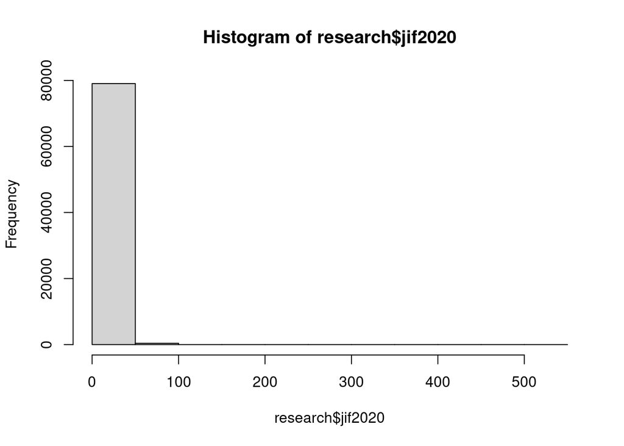

```r
hist(research$jif2020)
```

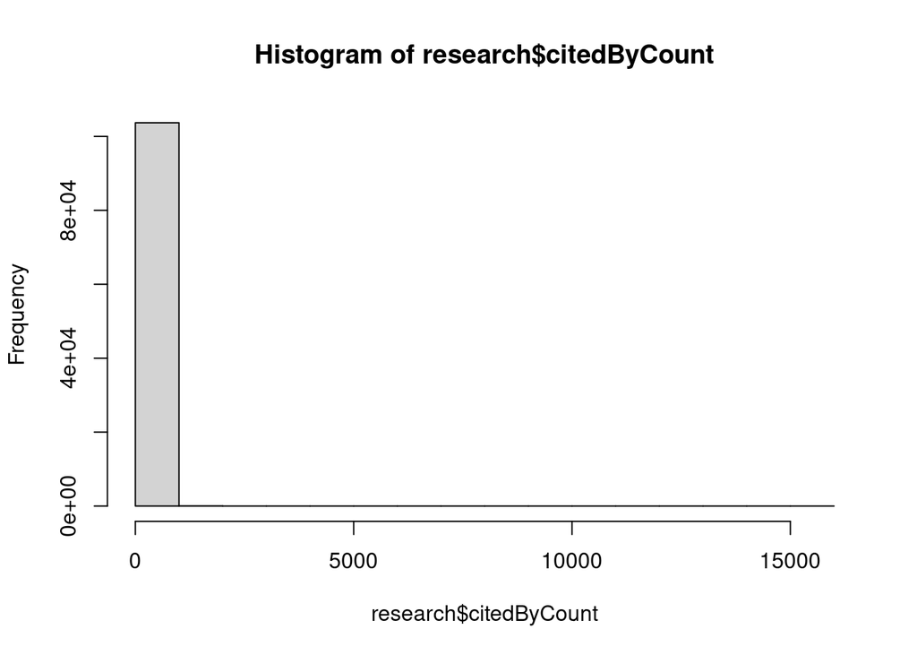

```r
hist(research$citedByCount)
```

```r
ad.test(research$jif2020)
```

```
##
##  Anderson-Darling normality test
##
## data:  research$jif2020
## A = 12697, p-value < 2.2e-16
```

```r
ad.test(research$citedByCount)
```

```
##
##  Anderson-Darling normality test
##
## data:  research$citedByCount
## A = 31331, p-value < 2.2e-16
```

JIF and citations based on COI disclosure:

```r
kable(research %>%
  group_by(is_coi_pred) %>%
  summarise(Median = round(median(jif2020, na.rm = T), 1),
            IQR = round(IQR(jif2020, na.rm = T), 2)))
```

| is_coi_pred | Median | IQR |
| --- | --- | --- |
| FALSE | 3.8 | 4.51 |
| TRUE | 3.7 | 2.43 |

```r
kable(research %>%
  group_by(is_coi_pred) %>%
  summarise(Median = round(median(citedByCount, na.rm = T), 1),
            IQR = round(IQR(citedByCount, na.rm = T), 2)))
```

| is_coi_pred | Median | IQR |
| --- | --- | --- |
| FALSE | 2 | 8 |
| TRUE | 2 | 7 |

Data was not normally distributed, hence we will use unpaired two-samples Wilcoxon test.

```r
wilcox.test(jif2020~is_coi_pred, data = research, exact = FALSE)
```

```
##
##  Wilcoxon rank sum test with continuity correction
##
## data:  jif2020 by is_coi_pred
## W = 323051860, p-value = 0.04525
## alternative hypothesis: true location shift is not equal to 0
```

```r
wilcox.test(citedByCount~is_coi_pred, data = research, exact = FALSE)
```

```
##
##  Wilcoxon rank sum test with continuity correction
##
## data:  citedByCount by is_coi_pred
## W = 613118372, p-value = 8.733e-14
## alternative hypothesis: true location shift is not equal to 0
```

JIF and citations based on funding disclosure:

```r
kable(research %>%
  group_by(is_fund_pred) %>%
  summarise(Median = round(median(jif2020, na.rm = T), 1),
            IQR = round(IQR(jif2020, na.rm = T), 2)))
```

| is_fund_pred | Median | IQR |
| --- | --- | --- |
| FALSE | 3.6 | 2.98 |
| TRUE | 3.8 | 2.37 |

```r
kable(research %>%
  group_by(is_fund_pred) %>%
  summarise(Median = round(median(citedByCount, na.rm = T), 1),
            IQR = round(IQR(citedByCount, na.rm = T), 2)))
```

| is_fund_pred | Median | IQR |
| --- | --- | --- |
| FALSE | 2 | 7 |
| TRUE | 2 | 7 |

Data was not normally distributed, hence we will use unpaired two-samples Wilcoxon test.

```r
wilcox.test(jif2020~is_fund_pred, data = research, exact = FALSE)
```

```
##
##  Wilcoxon rank sum test with continuity correction
##
## data:  jif2020 by is_fund_pred
## W = 545071477, p-value < 2.2e-16
## alternative hypothesis: true location shift is not equal to 0
```

```r
wilcox.test(citedByCount~is_fund_pred, data = research, exact = FALSE)
```

```
##
##  Wilcoxon rank sum test with continuity correction
##
## data:  citedByCount by is_fund_pred
## W = 1126068341, p-value = 3.151e-09
## alternative hypothesis: true location shift is not equal to 0
```

JIF and citations based on registration:

```r
kable(research %>%
  group_by(is_register_pred) %>%
  summarise(Median = round(median(jif2020, na.rm = T), 1),
            IQR = round(IQR(jif2020, na.rm = T), 2)))
```

| is_register_pred | Median | IQR |
| --- | --- | --- |
| FALSE | 3.7 | 2.48 |
| TRUE | 4.2 | 3.15 |

```r
kable(research %>%
  group_by(is_register_pred) %>%
  summarise(Median = round(median(citedByCount, na.rm = T), 1),
            IQR = round(IQR(citedByCount, na.rm = T), 2)))
```

| is_register_pred | Median | IQR |
| --- | --- | --- |
| FALSE | 2 | 7 |
| TRUE | 2 | 8 |

Data was not normally distributed, hence we will use unpaired two-samples Wilcoxon test.

```r
wilcox.test(jif2020~is_register_pred, data = research, exact = FALSE)
```

```
##
##  Wilcoxon rank sum test with continuity correction
##
## data:  jif2020 by is_register_pred
## W = 110524712, p-value < 2.2e-16
## alternative hypothesis: true location shift is not equal to 0
```

```r
wilcox.test(citedByCount~is_register_pred, data = research, exact = FALSE)
```

```
##
##  Wilcoxon rank sum test with continuity correction
##
## data:  citedByCount by is_register_pred
## W = 194829882, p-value = 0.398
## alternative hypothesis: true location shift is not equal to 0
```

JIF and citations based on data sharing:

```r
kable(research %>%
  group_by(is_open_data) %>%
  summarise(Median = round(median(jif2020, na.rm = T), 1),
            IQR = round(IQR(jif2020, na.rm = T), 2)))
```

| is_open_data | Median | IQR |
| --- | --- | --- |
| FALSE | 3.7 | 2.47 |
| TRUE | 4.4 | 4.03 |

```r
kable(research %>%
  group_by(is_open_data) %>%
  summarise(Median = round(median(citedByCount, na.rm = T), 1),
            IQR = round(IQR(citedByCount, na.rm = T), 2)))
```

| is_open_data | Median | IQR |
| --- | --- | --- |
| FALSE | 2 | 6 |
| TRUE | 2 | 9 |

Data was not normally distributed, hence we will use unpaired two-samples Wilcoxon test.

```r
wilcox.test(jif2020~is_open_data, data = research, exact = FALSE)
```

```
##
##  Wilcoxon rank sum test with continuity correction
##
## data:  jif2020 by is_open_data
## W = 260569392, p-value < 2.2e-16
## alternative hypothesis: true location shift is not equal to 0
```

```r
wilcox.test(citedByCount~is_open_data, data = research, exact = FALSE)
```

```
##
##  Wilcoxon rank sum test with continuity correction
##
## data:  citedByCount by is_open_data
## W = 463318978, p-value < 2.2e-16
## alternative hypothesis: true location shift is not equal to 0
```

JIF and citations based on code sharing:

```r
kable(research %>%
  group_by(is_open_code) %>%
  summarise(Median = round(median(jif2020, na.rm = T), 1),
            IQR = round(IQR(jif2020, na.rm = T), 2)))
```

| is_open_code | Median | IQR |
| --- | --- | --- |
| FALSE | 3.7 | 2.51 |
| TRUE | 4.6 | 5.64 |

```r
kable(research %>%
  group_by(is_open_code) %>%
  summarise(Median = round(median(citedByCount, na.rm = T), 1),
            IQR = round(IQR(citedByCount, na.rm = T), 2)))
```

| is_open_code | Median | IQR |
| --- | --- | --- |
| FALSE | 2 | 7 |
| TRUE | 2 | 9 |

Data was not normally distributed, hence we will use unpaired two-samples Wilcoxon test.

```r
wilcox.test(jif2020~is_open_code, data = research, exact = FALSE)
```

```
##
##  Wilcoxon rank sum test with continuity correction
##
## data:  jif2020 by is_open_code
## W = 86646598, p-value < 2.2e-16
## alternative hypothesis: true location shift is not equal to 0
```

```r
wilcox.test(citedByCount~is_open_code, data = research, exact = FALSE)
```

```
##
##  Wilcoxon rank sum test with continuity correction
##
## data:  citedByCount by is_open_code
## W = 176473202, p-value < 2.2e-16
## alternative hypothesis: true location shift is not equal to 0
```

## Monthly trend

Figure 1:

```r
proportions <- research %>%
        summarise("COI Disclosure" = sum(is_coi_pred == TRUE),
                  "Funding disclosure" = sum(is_fund_pred == TRUE),
                  "Protocol registration" = sum(is_register_pred == TRUE),
                  "Data sharing" = sum(is_open_data == TRUE),
                  "Code sharing" = sum(is_open_code == TRUE)) %>%
        t() %>%
        as.data.frame() %>%
        rownames_to_column(var = "indicator") %>%
        mutate(percentage = round(V1/nrow(research)*100, 1))

p1 <- proportions %>% ggplot() +
        aes(x = reorder(indicator, V1),
            y = V1,
            fill = indicator,
            col = indicator) +
        geom_col(alpha = 0.75) +
        geom_text(aes(label = percentage), hjust = -0.1, size = 3) +
        scale_y_continuous(
                name = "\nNumber of articles (in ten thousands)",
                breaks = seq(0, 10E4, 5E4),
                labels = seq(0, 10, 5),
                expand = expansion(mult = c(0, 0.2))
                ) +
        coord_flip() +
        xlab(NULL) +
        theme(
                legend.position = "none",
                panel.grid.major.y = element_blank()
        )
```

For the line grapht, first, we add the real publication year and month to the datasets. The real publication year/month is the year/month the paper was first appear online stored in firstPublicationDate column.

```r
research$YearMonth <- format(as.Date(research$firstPublicationDate), "%Y-%m")
```

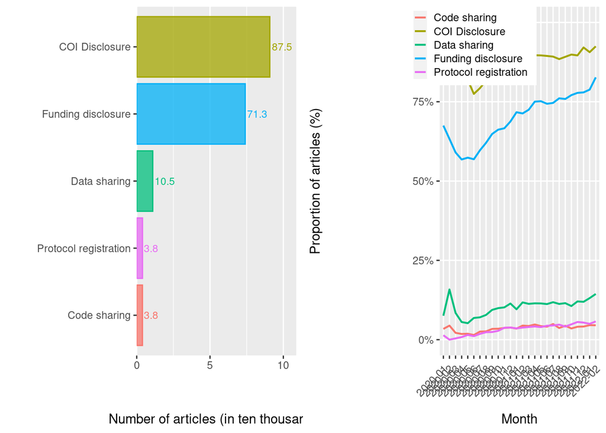

```r
indicator_by_year <-
        research %>%
        select(YearMonth,
               is_coi_pred,
               is_fund_pred,
               is_register_pred,
               is_open_data,
               is_open_code) %>%
        gather("indicator", "value", -YearMonth) %>%
        count(YearMonth, indicator, value) %>%
        mutate(indicator = recode(indicator,
                                  is_coi_pred = "COI Disclosure",
                                  is_fund_pred = "Funding disclosure",
                                  is_register_pred = "Protocol registration",
                                  is_open_data = "Data sharing",
                                  is_open_code = "Code sharing")) %>%
        complete(indicator, value, YearMonth, fill = list(n = 0)) %>%
        group_by(YearMonth, indicator) %>%
        mutate(p = n / sum(n)) %>%
        filter(value) %>%
        ungroup()

p2 <-
        indicator_by_year %>%
        ggplot() +
        aes(x = YearMonth,
            y = p,
            group = indicator,
            color = indicator) +
        geom_line(size = 0.75) +
        scale_y_continuous(limits = c(0, 1),
                           labels = scales::percent) +
        scale_color_discrete(name = NULL) +
        scale_fill_discrete(breaks = c("COI Disclosure",
                                       "Funding disclosure",
                                       "Protocol registration",
                                       "Data sharing",
                                       "Code sharing")) +
        labs(y = "Proportion of articles (%)\n",
             x = "\nMonth") +
        theme(panel.grid.minor = element_blank(),
              legend.position = c(0.2, 0.9),
              axis.text.x = element_text(angle = 45, vjust = 0.9, hjust=1),
              legend.key.size = unit(0.4, 'cm')
              )

figure <- ggarrange(p1, p2,
                    ncol = 2, nrow = 1,
                    align = "hv", common.legend = F)

# tiff("Figure.tiff", width = 14, height = 7, units = "in", res = 300)
figure
```

```r
#dev.off()
```

## Review papers

First, we subset the data to only include review papers using is_review variable:

```r
review <- opendata %>% filter(is_review == TRUE)
```

Number of open access papers per year:

```r
kable(table(review$year_firstpub))
```

| Var1 | Freq |
| --- | --- |
| 2020 | 7519 |
| 2021 | 9122 |
| 2022 | 994 |

The number of journals in our dataset:

```r
length(table(review$journalTitle))
```

```
## [1] 3016
```

Top 10 journals with the highest number of articles in our dataset, from high to low:

```r
kable(head(table(review$journalTitle)
           %>% as.data.frame()
           %>% arrange(desc(Freq)), 10))
```

| Var1 | Freq |
| --- | --- |
| Int J Environ Res Public Health | 342 |
| Int J Mol Sci | 278 |
| Front Immunol | 272 |
| J Clin Med | 198 |
| J Glob Health | 188 |
| Medicine (Baltimore) | 174 |
| Vaccines (Basel) | 165 |
| Viruses | 154 |
| Front Pharmacol | 151 |
| Int J Infect Dis | 110 |

Also, same table, but with all the journals

```r
review %>%
        mutate(journal = fct_lump_prop(journalTitle, prop = 0.01) ) %>%
        count(journal) %>%
        arrange(desc(n)) %>%
        knitr::kable()
```

| journal | n |
| --- | --- |
| Other | 16357 |
| Int J Environ Res Public Health | 342 |
| Int J Mol Sci | 278 |
| Front Immunol | 272 |
| J Clin Med | 198 |
| J Glob Health | 188 |

The mean and the median of the number of citations to these references:

```r
kable(data.frame(Mean = round(mean(review$citedByCount),1),
           SD = round(sd(review$citedByCount), 2),
           Median = median(review$citedByCount),
           IQR = IQR(review$citedByCount)
           ))
```

| Mean | SD | Median | IQR |
| --- | --- | --- | --- |
| 14.4 | 59.13 | 3 | 10 |

Characteristics of the paper with the highest number of citations:

```r
kable(review[which.max(review$citedByCount),] %>%
  select(citedByCount, pmid, pmcid, doi, title, authorString, journalTitle, year_firstpub))
```

|  | citedByCount | pmid | pmcid | doi | title | authorString | journalTitle | year_firstpub |
| --- | --- | --- | --- | --- | --- | --- | --- | --- |
| 1563 | 3307 | 32112714 | PMC7158942 | 10.1016/S0140-6736(20)30460-8 | The psychological impact of quarantine and how to reduce it: rapid review of the evidence. | Brooks SK, Webster RK, Smith LE, Woodland L, Wessely S, Greenberg N, Rubin GJ. | Lancet | 2020 |

The number and percentage of papers with a conflict of interest (CoI) disclosure:

```r
kable(data.frame(
  number = length(review$is_coi_pred[review$is_coi_pred == TRUE]),
           percentage = round(length(review$is_coi_pred[review$is_coi_pred == TRUE])/nrow(review)*100, 1)
           ))
```

| number | percentage |
| --- | --- |
| 16114 | 91.4 |

Confidence interval for CoI:

```r
kable(round(epi.prev(pos = length(review$is_coi_pred[review$is_coi_pred == TRUE]),
         tested = nrow(review),
         se = 0.992,
         sp = 0.995)$ap,
      1))
```

| est | lower | upper |
| --- | --- | --- |
| 91.4 | 91 | 91.8 |

Comparing CoI disclosure rate in three years:

```r
kable(round(prop.table(table(review$is_coi_pred, review$year_firstpub), 2)*100, 1))
```

|  | 2020 | 2021 | 2022 |
| --- | --- | --- | --- |
| FALSE | 11.5 | 6.7 | 4.7 |
| TRUE | 88.5 | 93.3 | 95.3 |

Chi-square test:

```r
chisq.test(review$is_coi_pred, review$year_firstpub)
```

```
##
##  Pearson's Chi-squared test
##
## data:  review$is_coi_pred and review$year_firstpub
## X-squared = 140.98, df = 2, p-value < 2.2e-16
```

The number and percentage of papers with a funding statement:

```r
kable(data.frame(number = length(review$is_fund_pred[review$is_fund_pred == TRUE]),
           percentage = round(length(review$is_fund_pred[review$is_fund_pred == TRUE])/nrow(review)*100, 1)
           ))
```

| number | percentage |
| --- | --- |
| 12034 | 68.2 |

Confidence interval for funding statement:

```r
kable(round(epi.prev(pos = length(review$is_fund_pred[review$is_fund_pred == TRUE]),
         tested = nrow(review),
         se = 0.997,
         sp = 0.981)$ap,
      1))
```

| est | lower | upper |
| --- | --- | --- |
| 68.2 | 67.5 | 68.9 |

Comparing funding statement rate in three years:

```r
kable(round(prop.table(table(review$is_fund_pred, review$year_firstpub), 2)*100, 1))
```

|  | 2020 | 2021 | 2022 |
| --- | --- | --- | --- |
| FALSE | 37.1 | 28.5 | 21.9 |
| TRUE | 62.9 | 71.5 | 78.1 |

Chi-square test:

```r
chisq.test(review$is_fund_pred, review$year_firstpub)
```

```
##
##  Pearson's Chi-squared test
##
## data:  review$is_fund_pred and review$year_firstpub
## X-squared = 187.85, df = 2, p-value < 2.2e-16
```

The number and percentage of papers that were registered beforehand:

```r
kable(data.frame(number = length(review$is_register_pred[review$is_register_pred == TRUE]),
           percentage = round(length(review$is_register_pred[review$is_register_pred == TRUE])/nrow(review)*100, 1)
           ))
```

| number | percentage |
| --- | --- |
| 774 | 4.4 |

Confidence interval for registration:

```r
kable(round(epi.prev(pos = length(review$is_register_pred[review$is_register_pred == TRUE]),
         tested = nrow(review),
         se = 0.955,
         sp = 0.997)$ap,
      1))
```

| est | lower | upper |
| --- | --- | --- |
| 4.4 | 4.1 | 4.7 |

Comparing registration rate in three years:

```r
kable(round(prop.table(table(review$is_register_pred, review$year_firstpub), 2)*100, 1))
```

|  | 2020 | 2021 | 2022 |
| --- | --- | --- | --- |
| FALSE | 96.9 | 95 | 91.6 |
| TRUE | 3.1 | 5 | 8.4 |

Chi-square test:

```r
chisq.test(review$is_register_pred, review$year_firstpub)
```

```
##
##  Pearson's Chi-squared test
##
## data:  review$is_register_pred and review$year_firstpub
## X-squared = 77.525, df = 2, p-value < 2.2e-16
```

The number and percentage of papers that shared data:

```r
kable(data.frame(number = length(review$is_open_data[review$is_open_data == TRUE]),
           percentage = round(length(review$is_open_data[review$is_open_data == TRUE])/nrow(review)*100, 1)
           ))
```

| number | percentage |
| --- | --- |
| 427 | 2.4 |

Confidence interval for data sharing:

```r
kable(round(epi.prev(pos = length(review$is_open_data[review$is_open_data == TRUE]),
         tested = nrow(review),
         se = 0.758,
         sp = 0.986)$ap,
      1))
```

| est | lower | upper |
| --- | --- | --- |
| 2.4 | 2.2 | 2.7 |

Comparing data sharing rate in three years:

```r
kable(round(prop.table(table(review$is_open_data, review$year_firstpub), 2)*100, 1))
```

|  | 2020 | 2021 | 2022 |
| --- | --- | --- | --- |
| FALSE | 97.6 | 97.6 | 97.4 |
| TRUE | 2.4 | 2.4 | 2.6 |

Chi-square test:

```r
chisq.test(review$is_open_data, review$year_firstpub)
```

```
##
##  Pearson's Chi-squared test
##
## data:  review$is_open_data and review$year_firstpub
## X-squared = 0.18289, df = 2, p-value = 0.9126
```

The number and percentage of papers that shared code:

```r
kable(data.frame(number = length(review$is_open_code[review$is_open_code == TRUE]),
           percentage = round(length(review$is_open_code[review$is_open_code == TRUE])/nrow(review)*100, 1)
           ))
```

| number | percentage |
| --- | --- |
| 78 | 0.4 |

Confidence interval for sharing code:

```r
kable(round(epi.prev(pos = length(review$is_open_code[review$is_open_code == TRUE]),
         tested = nrow(review),
         se = 0.587,
         sp = 0.997)$ap,
      1))
```

| est | lower | upper |
| --- | --- | --- |
| 0.4 | 0.4 | 0.6 |

Comparing sharing code rate in three years:

```r
kable(round(prop.table(table(review$is_open_code, review$year_firstpub), 2)*100, 1))
```

|  | 2020 | 2021 | 2022 |
| --- | --- | --- | --- |
| FALSE | 99.8 | 99.5 | 98.8 |
| TRUE | 0.2 | 0.5 | 1.2 |

Chi-square test:

```r
chisq.test(review$is_open_code, review$year_firstpub)
```

```
##
##  Pearson's Chi-squared test
##
## data:  review$is_open_code and review$year_firstpub
## X-squared = 23.054, df = 2, p-value = 9.858e-06
```

Sum of five indicators:

```r
review %>% mutate(sum = rowSums(review %>% select(is_coi_pred, is_register_pred, is_fund_pred, is_open_data, is_open_code))) %>% select(sum) %>% tbl_summary()
```

| **Characteristic** | **N = 17,635**<sup>1</sup> |
| --- | --- |
| sum |  |
| 0 | 1,014 (5.7%) |
| 1 | 4,839 (27%) |
| 2 | 10,812 (61%) |
| 3 | 917 (5.2%) |
| 4 | 52 (0.3%) |
| 5 | 1 (<0.1%) |

<sup>1</sup> n (%)

## Journal-related differences in transparency (Table 1)

Total number of papers published in journals with a JIF:

```r
table(is.na(review$jif2020))
```

```
##
## FALSE  TRUE
## 13835  3800
```

Five highest impact journals

```r
tapply(review$jif2020, review$journalTitle, max) %>% as.data.frame() %>% arrange(desc(.)) %>% head(5)
```

```
##                             .
## CA Cancer J Clin      508.702
## Nat Rev Mol Cell Biol  94.444
## N Engl J Med           91.245
## Nat Rev Drug Discov    84.694
## Lancet                 79.321
```

```r
review$jif2020c = ifelse(review$jif2020 < 79.321,"Other", review$journalTitle)
```

Table 1A

```r
set.seed(100)
review %>%
  select(journalTitle,is_coi_pred,is_fund_pred,is_register_pred,is_open_data,is_open_code) %>%
        mutate(journalTitle = fct_lump(journalTitle,n=5)) %>%
  tbl_summary(by=journalTitle, percent="column",
              label = c(is_coi_pred ~ "COI disclosure", is_fund_pred ~ "Funding disclosure", is_register_pred ~ "Protocol registration", is_open_data ~ "Data sharing", is_open_code ~ "Code sharing")) %>%
  add_p(test.args=all_tests("fisher.test") ~ list(simulate.p.value=TRUE)) %>%
        as_flex_table()
```

| Characteristic | Front Immunol, N = 2721 | Int J Environ Res Public Health, N = 3421 | Int J Mol Sci, N = 2781 | J Clin Med, N = 1981 | J Glob Health, N = 1881 | Other, N = 16,3571 | p-value2 |
| --- | --- | --- | --- | --- | --- | --- | --- |
| COI disclosure | 272 (100%) | 342 (100%) | 278 (100%) | 198 (100%) | 187 (99%) | 14,837 (91%) | <0.001 |
| Funding disclosure | 209 (77%) | 342 (100%) | 275 (99%) | 196 (99%) | 185 (98%) | 10,827 (66%) | <0.001 |
| Protocol registration | 2 (0.7%) | 35 (10%) | 0 (0%) | 15 (7.6%) | 0 (0%) | 722 (4.4%) | <0.001 |
| Data sharing | 0 (0%) | 8 (2.3%) | 8 (2.9%) | 7 (3.5%) | 0 (0%) | 404 (2.5%) | 0.002 |
| Code sharing | 0 (0%) | 3 (0.9%) | 0 (0%) | 0 (0%) | 0 (0%) | 75 (0.5%) | 0.6 |

1n (%)  
2Pearson's Chi-squared test; Fisher's Exact Test for Count Data with simulated p-value (based on 2000 replicates)

Table 1B

```r
set.seed(100)
review %>%
  select(jif2020c,is_coi_pred,is_fund_pred,is_register_pred,is_open_data,is_open_code) %>%
  tbl_summary(by=jif2020c, percent="column",
              label = c(is_coi_pred ~ "COI disclosure", is_fund_pred ~ "Funding disclosure", is_register_pred ~ "Protocol registration", is_open_data ~ "Data sharing", is_open_code ~ "Code sharing")) %>%
  add_p(test.args=all_tests("fisher.test") ~ list(simulate.p.value=TRUE)) %>%
        as_flex_table()
```

```
## 3800 observations missing `jif2020c` have been removed. To include these observations, use `forcats::fct_explicit_na()` on `jif2020c` column before passing to `tbl_summary()`.
```

| Characteristic | CA Cancer J Clin, N = 21 | Lancet, N = 261 | N Engl J Med, N = 31 | Nat Rev Drug Discov, N = 21 | Nat Rev Mol Cell Biol, N = 21 | Other, N = 13,8001 | p-value2 |
| --- | --- | --- | --- | --- | --- | --- | --- |
| COI disclosure | 1 (50%) | 26 (100%) | 3 (100%) | 2 (100%) | 2 (100%) | 12,589 (91%) | 0.2 |
| Funding disclosure | 1 (50%) | 18 (69%) | 0 (0%) | 1 (50%) | 2 (100%) | 9,743 (71%) | 0.076 |
| Protocol registration | 0 (0%) | 0 (0%) | 0 (0%) | 0 (0%) | 0 (0%) | 673 (4.9%) | 0.8 |
| Data sharing | 0 (0%) | 0 (0%) | 0 (0%) | 0 (0%) | 0 (0%) | 356 (2.6%) | >0.9 |
| Code sharing | 0 (0%) | 0 (0%) | 0 (0%) | 0 (0%) | 0 (0%) | 56 (0.4%) | >0.9 |

1n (%)  
2Fisher's Exact Test for Count Data with simulated p-value (based on 2000 replicates)

## Publisher-related differences in transparency (Table 2)

Table 2

```r
set.seed(100)
review %>%
  select(scimago_publisher,is_coi_pred,is_fund_pred,is_register_pred,is_open_data,is_open_code) %>%
        mutate(scimago_publisher = fct_lump(scimago_publisher,n=6)) %>%
  tbl_summary(by=scimago_publisher, percent="column",
              label = c(is_coi_pred ~ "COI disclosure", is_fund_pred ~ "Funding disclosure", is_register_pred ~ "Protocol registration", is_open_data ~ "Data sharing", is_open_code ~ "Code sharing")) %>%
  add_p(test.args=all_tests("fisher.test") ~ list(simulate.p.value=TRUE)) %>%
        as_flex_table()
```

```
## 3019 observations missing `scimago_publisher` have been removed. To include these observations, use `forcats::fct_explicit_na()` on `scimago_publisher` column before passing to `tbl_summary()`.
```

| Characteristic | Elsevier, N = 7091 | Elsevier BV, N = 7051 | Elsevier Ltd., N = 5361 | Frontiers Media S.A., N = 8491 | MDPI Multidisciplinary Digital Publishing Institute, N = 1,4451 | Wiley-Blackwell Publishing Ltd, N = 4601 | Other, N = 9,9121 | p-value2 |
| --- | --- | --- | --- | --- | --- | --- | --- | --- |
| COI disclosure | 637 (90%) | 650 (92%) | 432 (81%) | 849 (100%) | 1,445 (100%) | 318 (69%) | 8,909 (90%) | <0.001 |
| Funding disclosure | 527 (74%) | 527 (75%) | 366 (68%) | 573 (67%) | 1,441 (100%) | 180 (39%) | 6,362 (64%) | <0.001 |
| Protocol registration | 29 (4.1%) | 26 (3.7%) | 11 (2.1%) | 16 (1.9%) | 47 (3.3%) | 24 (5.2%) | 529 (5.3%) | <0.001 |
| Data sharing | 35 (4.9%) | 21 (3.0%) | 21 (3.9%) | 8 (0.9%) | 34 (2.4%) | 19 (4.1%) | 225 (2.3%) | <0.001 |
| Code sharing | 3 (0.4%) | 2 (0.3%) | 3 (0.6%) | 2 (0.2%) | 8 (0.6%) | 1 (0.2%) | 49 (0.5%) | >0.9 |

1n (%)  
2Pearson's Chi-squared test; Fisher's Exact Test for Count Data with simulated p-value (based on 2000 replicates)

## Journal Impact Factor (JIF) and citation count analyses (Table 3)

Total number of papers published in journals with no JIF:

```r
sum(is.na(review$jif2020))
```

```
## [1] 3800
```

Normality of JIFs and citations

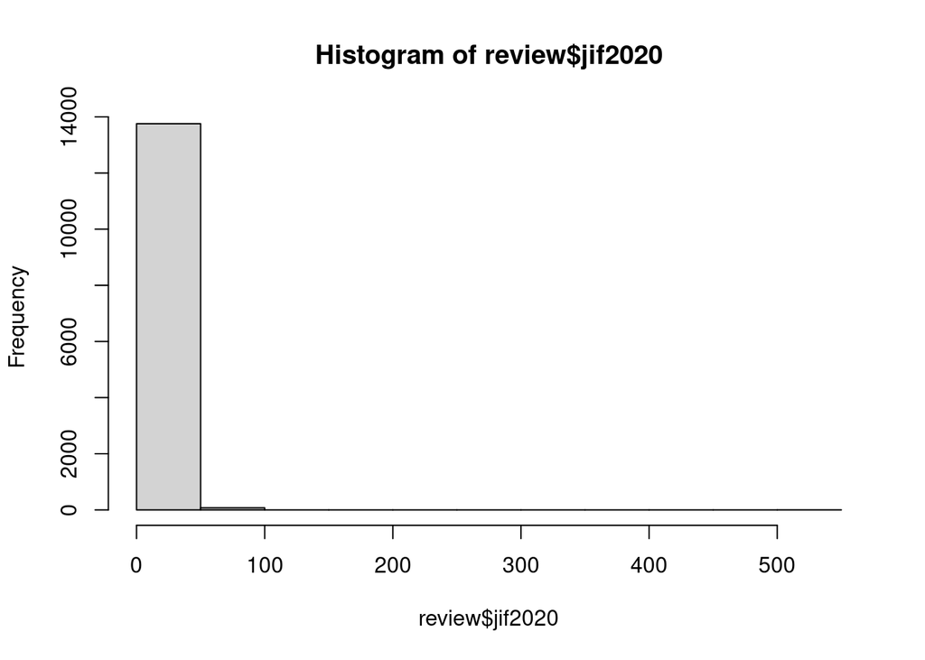

```r
hist(review$jif2020)
```

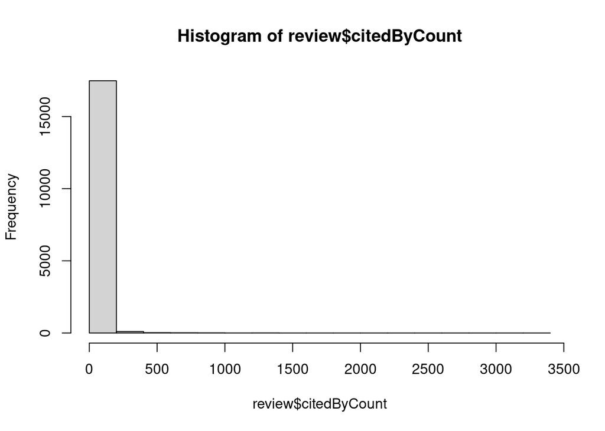

```r
hist(review$citedByCount)
```

```r
ad.test(review$jif2020)
```

```
##
##  Anderson-Darling normality test
##
## data:  review$jif2020
## A = 2414.6, p-value < 2.2e-16
```

```r
ad.test(review$citedByCount)
```

```
##
##  Anderson-Darling normality test
##
## data:  review$citedByCount
## A = 4229.9, p-value < 2.2e-16
```

JIF and citations based on COI disclosure:

```r
kable(review %>%
  group_by(is_coi_pred) %>%
  summarise(Median = round(median(jif2020, na.rm = T), 1),
            IQR = round(IQR(jif2020, na.rm = T), 2)))
```

| is_coi_pred | Median | IQR |
| --- | --- | --- |
| FALSE | 4.4 | 4.49 |
| TRUE | 4.4 | 2.72 |

```r
kable(review %>%
  group_by(is_coi_pred) %>%
  summarise(Median = round(median(citedByCount, na.rm = T), 1),
            IQR = round(IQR(citedByCount, na.rm = T), 2)))
```

| is_coi_pred | Median | IQR |
| --- | --- | --- |
| FALSE | 5 | 15 |
| TRUE | 3 | 10 |

Data was not normally distributed, hence we will use unpaired two-samples Wilcoxon test.

```r
wilcox.test(jif2020~is_coi_pred, data = review, exact = FALSE)
```

```
##
##  Wilcoxon rank sum test with continuity correction
##
## data:  jif2020 by is_coi_pred
## W = 7797304, p-value = 0.2659
## alternative hypothesis: true location shift is not equal to 0
```

```r
wilcox.test(citedByCount~is_coi_pred, data = review, exact = FALSE)
```

```
##
##  Wilcoxon rank sum test with continuity correction
##
## data:  citedByCount by is_coi_pred
## W = 13827717, p-value < 2.2e-16
## alternative hypothesis: true location shift is not equal to 0
```

JIF and citations based on funding disclosure:

```r
kable(review %>%
  group_by(is_fund_pred) %>%
  summarise(Median = round(median(jif2020, na.rm = T), 1),
            IQR = round(IQR(jif2020, na.rm = T), 2)))
```

| is_fund_pred | Median | IQR |
| --- | --- | --- |
| FALSE | 4.1 | 3.05 |
| TRUE | 4.5 | 2.85 |

```r
kable(review %>%
  group_by(is_fund_pred) %>%
  summarise(Median = round(median(citedByCount, na.rm = T), 1),
            IQR = round(IQR(citedByCount, na.rm = T), 2)))
```

| is_fund_pred | Median | IQR |
| --- | --- | --- |
| FALSE | 3 | 10 |
| TRUE | 3 | 11 |

Data was not normally distributed, hence we will use unpaired two-samples Wilcoxon test.

```r
wilcox.test(jif2020~is_fund_pred, data = review, exact = FALSE)
```

```
##
##  Wilcoxon rank sum test with continuity correction
##
## data:  jif2020 by is_fund_pred
## W = 17406636, p-value < 2.2e-16
## alternative hypothesis: true location shift is not equal to 0
```

```r
wilcox.test(citedByCount~is_fund_pred, data = review, exact = FALSE)
```

```
##
##  Wilcoxon rank sum test with continuity correction
##
## data:  citedByCount by is_fund_pred
## W = 34592139, p-value = 0.00428
## alternative hypothesis: true location shift is not equal to 0
```

JIF and citations based on registration:

```r
kable(review %>%
  group_by(is_register_pred) %>%
  summarise(Median = round(median(jif2020, na.rm = T), 1),
            IQR = round(IQR(jif2020, na.rm = T), 2)))
```

| is_register_pred | Median | IQR |
| --- | --- | --- |
| FALSE | 4.4 | 2.94 |
| TRUE | 3.3 | 2.66 |

```r
kable(review %>%
  group_by(is_register_pred) %>%
  summarise(Median = round(median(citedByCount, na.rm = T), 1),
            IQR = round(IQR(citedByCount, na.rm = T), 2)))
```

| is_register_pred | Median | IQR |
| --- | --- | --- |
| FALSE | 3 | 10 |
| TRUE | 2 | 7 |

Data was not normally distributed, hence we will use unpaired two-samples Wilcoxon test.

```r
wilcox.test(jif2020~is_register_pred, data = review, exact = FALSE)
```

```
##
##  Wilcoxon rank sum test with continuity correction
##
## data:  jif2020 by is_register_pred
## W = 5893046, p-value < 2.2e-16
## alternative hypothesis: true location shift is not equal to 0
```

```r
wilcox.test(citedByCount~is_register_pred, data = review, exact = FALSE)
```

```
##
##  Wilcoxon rank sum test with continuity correction
##
## data:  citedByCount by is_register_pred
## W = 7456798, p-value = 1.133e-11
## alternative hypothesis: true location shift is not equal to 0
```

JIF and citations based on data sharing:

```r
kable(review %>%
  group_by(is_open_data) %>%
  summarise(Median = round(median(jif2020, na.rm = T), 1),
            IQR = round(IQR(jif2020, na.rm = T), 2)))
```

| is_open_data | Median | IQR |
| --- | --- | --- |
| FALSE | 4.4 | 2.86 |
| TRUE | 4.8 | 2.92 |

```r
kable(review %>%
  group_by(is_open_data) %>%
  summarise(Median = round(median(citedByCount, na.rm = T), 1),
            IQR = round(IQR(citedByCount, na.rm = T), 2)))
```

| is_open_data | Median | IQR |
| --- | --- | --- |
| FALSE | 3 | 10.0 |
| TRUE | 4 | 16.5 |

Data was not normally distributed, hence we will use unpaired two-samples Wilcoxon test.

```r
wilcox.test(jif2020~is_open_data, data = review, exact = FALSE)
```

```
##
##  Wilcoxon rank sum test with continuity correction
##
## data:  jif2020 by is_open_data
## W = 2292968, p-value = 0.153
## alternative hypothesis: true location shift is not equal to 0
```

```r
wilcox.test(citedByCount~is_open_data, data = review, exact = FALSE)
```

```
##
##  Wilcoxon rank sum test with continuity correction
##
## data:  citedByCount by is_open_data
## W = 3272269, p-value = 9.599e-05
## alternative hypothesis: true location shift is not equal to 0
```

JIF and citations based on code sharing:

```r
kable(review %>%
  group_by(is_open_code) %>%
  summarise(Median = round(median(jif2020, na.rm = T), 1),
            IQR = round(IQR(jif2020, na.rm = T), 2)))
```

| is_open_code | Median | IQR |
| --- | --- | --- |
| FALSE | 4.4 | 2.86 |
| TRUE | 4.9 | 3.13 |

```r
kable(review %>%
  group_by(is_open_code) %>%
  summarise(Median = round(median(citedByCount, na.rm = T), 1),
            IQR = round(IQR(citedByCount, na.rm = T), 2)))
```

| is_open_code | Median | IQR |
| --- | --- | --- |
| FALSE | 3 | 10 |
| TRUE | 2 | 6 |

Data was not normally distributed, hence we will use unpaired two-samples Wilcoxon test.

```r
wilcox.test(jif2020~is_open_code, data = review, exact = FALSE)
```

```
##
##  Wilcoxon rank sum test with continuity correction
##
## data:  jif2020 by is_open_code
## W = 362920, p-value = 0.4428
## alternative hypothesis: true location shift is not equal to 0
```

```r
wilcox.test(citedByCount~is_open_code, data = review, exact = FALSE)
```

```
##
##  Wilcoxon rank sum test with continuity correction
##
## data:  citedByCount by is_open_code
## W = 778110, p-value = 0.03566
## alternative hypothesis: true location shift is not equal to 0
```

## Monthly trend

Figure 1:

```r
proportions <- review %>%
        summarise("COI Disclosure" = sum(is_coi_pred == TRUE),
                  "Funding disclosure" = sum(is_fund_pred == TRUE),
                  "Protocol registration" = sum(is_register_pred == TRUE),
                  "Data sharing" = sum(is_open_data == TRUE),
                  "Code sharing" = sum(is_open_code == TRUE)) %>%
        t() %>%
        as.data.frame() %>%
        rownames_to_column(var = "indicator") %>%
        mutate(percentage = round(V1/nrow(review)*100, 1))

p1 <- proportions %>% ggplot() +
        aes(x = reorder(indicator, V1),
            y = V1,
            fill = indicator,
            col = indicator) +
        geom_col(alpha = 0.75) +
        geom_text(aes(label = percentage), hjust = -0.1, size = 3) +
        scale_y_continuous(
                name = "\nNumber of articles (in ten thousands)",
                breaks = seq(0, 10E4, 5E4),
                labels = seq(0, 10, 5),
                expand = expansion(mult = c(0, 0.2))
                ) +
        coord_flip() +
        xlab(NULL) +
        theme(
                legend.position = "none",
                panel.grid.major.y = element_blank()
        )
```

For the line grapht, first, we add the real publication year and month to the datasets. The real publication year/month is the year/month the paper was first appear online stored in firstPublicationDate column.

```r
review$YearMonth <- format(as.Date(review$firstPublicationDate), "%Y-%m")
```

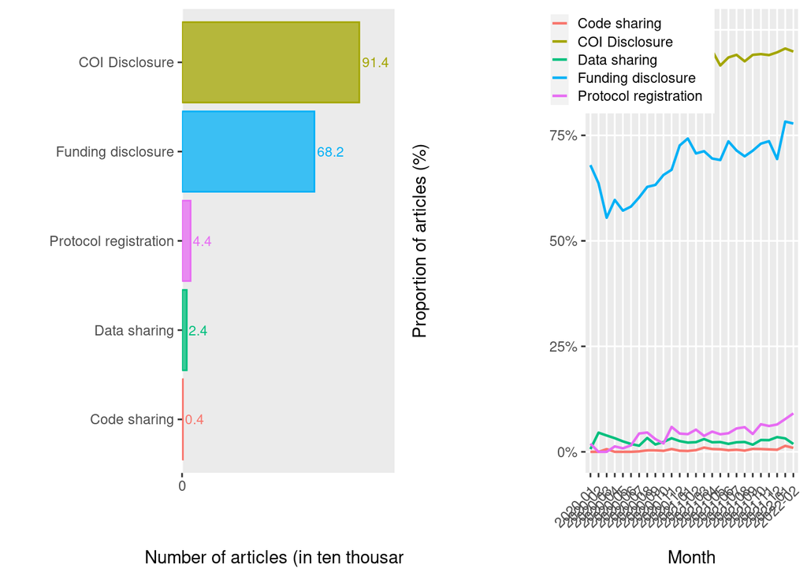

```r
indicator_by_year <-
        review %>%
        select(YearMonth,
               is_coi_pred,
               is_fund_pred,
               is_register_pred,
               is_open_data,
               is_open_code) %>%
        gather("indicator", "value", -YearMonth) %>%
        count(YearMonth, indicator, value) %>%
        mutate(indicator = recode(indicator,
                                  is_coi_pred = "COI Disclosure",
                                  is_fund_pred = "Funding disclosure",
                                  is_register_pred = "Protocol registration",
                                  is_open_data = "Data sharing",
                                  is_open_code = "Code sharing")) %>%
        complete(indicator, value, YearMonth, fill = list(n = 0)) %>%
        group_by(YearMonth, indicator) %>%
        mutate(p = n / sum(n)) %>%
        filter(value) %>%
        ungroup()

p2 <-
        indicator_by_year %>%
        ggplot() +
        aes(x = YearMonth,
            y = p,
            group = indicator,
            color = indicator) +
        geom_line(size = 0.75) +
        scale_y_continuous(limits = c(0, 1),
                           labels = scales::percent) +
        scale_color_discrete(name = NULL) +
        scale_fill_discrete(breaks = c("COI Disclosure",
                                       "Funding disclosure",
                                       "Protocol registration",
                                       "Data sharing",
                                       "Code sharing")) +
        labs(y = "Proportion of articles (%)\n",
             x = "\nMonth") +
        theme(panel.grid.minor = element_blank(),
              legend.position = c(0.2, 0.9),
              axis.text.x = element_text(angle = 45, vjust = 0.9, hjust=1),
              legend.key.size = unit(0.4, 'cm')
              )

figure <- ggarrange(p1, p2,
                    ncol = 2, nrow = 1,
                    align = "hv", common.legend = F)

# tiff("Figure.tiff", width = 14, height = 7, units = "in", res = 300)
figure
```

```r
#dev.off()
```

## Other papers

First, we subset the data to non-research non-review papers using is_research and is_review variables:

```r
other <- opendata %>% filter(is_research == FALSE & is_review == FALSE)
```

Number of open access papers per year:

```r
kable(table(other$year_firstpub))
```

| Var1 | Freq |
| --- | --- |
| 2020 | 5690 |
| 2021 | 5110 |
| 2022 | 405 |

The number of journals in our dataset:

```r
length(table(other$journalTitle))
```

```
## [1] 1684
```

Top 10 journals with the highest number of articles in our dataset, from high to low:

```r
kable(head(table(other$journalTitle)
           %>% as.data.frame()
           %>% arrange(desc(Freq)), 10))
```

| Var1 | Freq |
| --- | --- |
| BMJ Case Rep | 398 |
| Lancet | 337 |
| Front Public Health | 204 |
| Lancet Respir Med | 165 |
| BMJ Open | 162 |
| Lancet Infect Dis | 152 |
| Ann Intern Med | 148 |
| Eur Heart J | 143 |
| BMJ Glob Health | 126 |
| Pan Afr Med J | 124 |

Also, same table, but with all the journals

```r
other %>%
        mutate(journal = fct_lump_prop(journalTitle, prop = 0.01) ) %>%
        count(journal) %>%
        arrange(desc(n)) %>%
        knitr::kable()
```

| journal | n |
| --- | --- |
| Other | 9128 |
| BMJ Case Rep | 398 |
| Lancet | 337 |
| Front Public Health | 204 |
| Lancet Respir Med | 165 |
| BMJ Open | 162 |
| Lancet Infect Dis | 152 |
| Ann Intern Med | 148 |
| Eur Heart J | 143 |
| BMJ Glob Health | 126 |
| Pan Afr Med J | 124 |
| EClinicalMedicine | 118 |

The mean and the median of the number of citations to these references:

```r
kable(data.frame(Mean = round(mean(other$citedByCount),1),
           SD = round(sd(other$citedByCount), 2),
           Median = median(other$citedByCount),
           IQR = IQR(other$citedByCount)
           ))
```

| Mean | SD | Median | IQR |
| --- | --- | --- | --- |
| 9.4 | 45.61 | 2 | 6 |

Characteristics of the paper with the highest number of citations:

```r
kable(other[which.max(other$citedByCount),] %>%
  select(citedByCount, pmid, pmcid, doi, title, authorString, journalTitle, year_firstpub))
```

|  | citedByCount | pmid | pmcid | doi | title | authorString | journalTitle | year_firstpub |
| --- | --- | --- | --- | --- | --- | --- | --- | --- |
| 1404 | 2225 | 31986257 | PMC7135038 | 10.1016/S0140-6736(20)30185-9 | A novel coronavirus outbreak of global health concern. | Wang C, Horby PW, Hayden FG, Gao GF. | Lancet | 2020 |

The number and percentage of papers with a conflict of interest (CoI) disclosure:

```r
kable(data.frame(
  number = length(other$is_coi_pred[other$is_coi_pred == TRUE]),
           percentage = round(length(other$is_coi_pred[other$is_coi_pred == TRUE])/nrow(other)*100, 1)
           ))
```

| number | percentage |
| --- | --- |
| 8512 | 76 |

Confidence interval for CoI:

```r
kable(round(epi.prev(pos = length(other$is_coi_pred[other$is_coi_pred == TRUE]),
         tested = nrow(other),
         se = 0.992,
         sp = 0.995)$ap,
      1))
```

| est | lower | upper |
| --- | --- | --- |
| 76 | 75.2 | 76.7 |

Comparing CoI disclosure rate in three years:

```r
kable(round(prop.table(table(other$is_coi_pred, other$year_firstpub), 2)*100, 1))
```

|  | 2020 | 2021 | 2022 |
| --- | --- | --- | --- |
| FALSE | 27.1 | 21 | 18.5 |
| TRUE | 72.9 | 79 | 81.5 |

Chi-square test:

```r
chisq.test(other$is_coi_pred, other$year_firstpub)
```

```
##
##  Pearson's Chi-squared test
##
## data:  other$is_coi_pred and other$year_firstpub
## X-squared = 62.189, df = 2, p-value = 3.133e-14
```

The number and percentage of papers with a funding statement:

```r
kable(data.frame(number = length(other$is_fund_pred[other$is_fund_pred == TRUE]),
           percentage = round(length(other$is_fund_pred[other$is_fund_pred == TRUE])/nrow(other)*100, 1)
           ))
```

| number | percentage |
| --- | --- |
| 5367 | 47.9 |

Confidence interval for funding statement:

```r
kable(round(epi.prev(pos = length(other$is_fund_pred[other$is_fund_pred == TRUE]),
         tested = nrow(other),
         se = 0.997,
         sp = 0.981)$ap,
      1))
```

| est | lower | upper |
| --- | --- | --- |
| 47.9 | 47 | 48.8 |

Comparing funding statement rate in three years:

```r
kable(round(prop.table(table(other$is_fund_pred, other$year_firstpub), 2)*100, 1))
```

|  | 2020 | 2021 | 2022 |
| --- | --- | --- | --- |
| FALSE | 57.7 | 46.5 | 44.9 |
| TRUE | 42.3 | 53.5 | 55.1 |

Chi-square test:

```r
chisq.test(other$is_fund_pred, other$year_firstpub)
```

```
##
##  Pearson's Chi-squared test
##
## data:  other$is_fund_pred and other$year_firstpub
## X-squared = 143.6, df = 2, p-value < 2.2e-16
```

The number and percentage of papers that were registered beforehand:

```r
kable(data.frame(number = length(other$is_register_pred[other$is_register_pred == TRUE]),
           percentage = round(length(other$is_register_pred[other$is_register_pred == TRUE])/nrow(other)*100, 1)
           ))
```

| number | percentage |
| --- | --- |
| 0 | 0 |

Since none have been registered, other tests is not possible.

The number and percentage of papers that shared data:

```r
kable(data.frame(number = length(other$is_open_data[other$is_open_data == TRUE]),
           percentage = round(length(other$is_open_data[other$is_open_data == TRUE])/nrow(other)*100, 1)
           ))
```

| number | percentage |
| --- | --- |
| 186 | 1.7 |

Confidence interval for data sharing:

```r
kable(round(epi.prev(pos = length(other$is_open_data[other$is_open_data == TRUE]),
         tested = nrow(other),
         se = 0.758,
         sp = 0.986)$ap,
      1))
```

| est | lower | upper |
| --- | --- | --- |
| 1.7 | 1.4 | 1.9 |

Comparing data sharing rate in three years:

```r
kable(round(prop.table(table(other$is_open_data, other$year_firstpub), 2)*100, 1))
```

|  | 2020 | 2021 | 2022 |
| --- | --- | --- | --- |
| FALSE | 98.5 | 98.1 | 98.3 |
| TRUE | 1.5 | 1.9 | 1.7 |

Chi-square test:

```r
chisq.test(other$is_open_data, other$year_firstpub)
```

```
##
##  Pearson's Chi-squared test
##
## data:  other$is_open_data and other$year_firstpub
## X-squared = 2.4291, df = 2, p-value = 0.2968
```

The number and percentage of papers that shared code:

```r
kable(data.frame(number = length(other$is_open_code[other$is_open_code == TRUE]),
           percentage = round(length(other$is_open_code[other$is_open_code == TRUE])/nrow(other)*100, 1)
           ))
```

| number | percentage |
| --- | --- |
| 67 | 0.6 |

Confidence interval for sharing code:

```r
kable(round(epi.prev(pos = length(other$is_open_code[other$is_open_code == TRUE]),
         tested = nrow(other),
         se = 0.587,
         sp = 0.997)$ap,
      1))
```

| est | lower | upper |
| --- | --- | --- |
| 0.6 | 0.5 | 0.8 |

Comparing sharing code rate in three years:

```r
kable(round(prop.table(table(other$is_open_code, other$year_firstpub), 2)*100, 1))
```

|  | 2020 | 2021 | 2022 |
| --- | --- | --- | --- |
| FALSE | 99.5 | 99.3 | 99.3 |
| TRUE | 0.5 | 0.7 | 0.7 |

Chi-square test:

```r
chisq.test(other$is_open_code, other$year_firstpub)
```

```
##
##  Pearson's Chi-squared test
##
## data:  other$is_open_code and other$year_firstpub
## X-squared = 2.965, df = 2, p-value = 0.2271
```

Sum of five indicators:

```r
other %>% mutate(sum = rowSums(other %>% select(is_coi_pred, is_register_pred, is_fund_pred, is_open_data, is_open_code))) %>% select(sum) %>% tbl_summary()
```

| **Characteristic** | **N = 11,205**<sup>1</sup> |
| --- | --- |
| sum |  |
| 0 | 2,313 (21%) |
| 1 | 3,831 (34%) |
| 2 | 4,901 (44%) |
| 3 | 141 (1.3%) |
| 4 | 19 (0.2%) |

<sup>1</sup> n (%)

## Journal-related differences in transparency (Table 1)

Total number of papers published in journals with a JIF:

```r
table(is.na(other$jif2020))
```

```
##
## FALSE  TRUE
##  8514  2691
```

Five highest impact journals

```r
tapply(other$jif2020, other$journalTitle, max) %>% as.data.frame() %>% arrange(desc(.)) %>% head(5)
```

```
##                      .
## N Engl J Med    91.245
## Lancet          79.321
## Nat Biotechnol  54.908
## Nat Med         53.440
## Nat Rev Immunol 53.106
```

```r
other$jif2020c = ifelse(other$jif2020 < 79.321,"Other", other$journalTitle)
```

Table 1A

```r
set.seed(100)
other %>%
  select(journalTitle,is_coi_pred,is_fund_pred,is_register_pred,is_open_data,is_open_code) %>%
        mutate(journalTitle = fct_lump(journalTitle,n=5)) %>%
  tbl_summary(by=journalTitle, percent="column",
              label = c(is_coi_pred ~ "COI disclosure", is_fund_pred ~ "Funding disclosure", is_register_pred ~ "Protocol registration", is_open_data ~ "Data sharing", is_open_code ~ "Code sharing")) %>%
  add_p(test.args=all_tests("fisher.test") ~ list(simulate.p.value=TRUE)) %>%
        as_flex_table()
```

```
## There was an error in 'add_p()/add_difference()' for variable 'is_register_pred', p-value omitted:
## Error in stats::chisq.test(x = c(FALSE, FALSE, FALSE, FALSE, FALSE, FALSE, : 'x' and 'y' must have at least 2 levels
```

| Characteristic | BMJ Case Rep, N = 3981 | BMJ Open, N = 1621 | Front Public Health, N = 2041 | Lancet, N = 3371 | Lancet Respir Med, N = 1651 | Other, N = 9,9391 | p-value2 |
| --- | --- | --- | --- | --- | --- | --- | --- |
| COI disclosure | 398 (100%) | 158 (98%) | 203 (100%) | 198 (59%) | 116 (70%) | 7,439 (75%) | <0.001 |
| Funding disclosure | 398 (100%) | 158 (98%) | 88 (43%) | 72 (21%) | 34 (21%) | 4,617 (46%) | <0.001 |
| Protocol registration | 0 (0%) | 0 (0%) | 0 (0%) | 0 (0%) | 0 (0%) | 0 (0%) |  |
| Data sharing | 1 (0.3%) | 20 (12%) | 3 (1.5%) | 2 (0.6%) | 0 (0%) | 160 (1.6%) | <0.001 |
| Code sharing | 0 (0%) | 0 (0%) | 3 (1.5%) | 1 (0.3%) | 0 (0%) | 63 (0.6%) | 0.2 |

1n (%)  
2Pearson's Chi-squared test; Fisher's Exact Test for Count Data with simulated p-value (based on 2000 replicates)

Table 1B

```r
set.seed(100)
other %>%
  select(jif2020c,is_coi_pred,is_fund_pred,is_register_pred,is_open_data,is_open_code) %>%
  tbl_summary(by=jif2020c, percent="column",
              label = c(is_coi_pred ~ "COI disclosure", is_fund_pred ~ "Funding disclosure", is_register_pred ~ "Protocol registration", is_open_data ~ "Data sharing", is_open_code ~ "Code sharing")) %>%
  add_p(test.args=all_tests("fisher.test") ~ list(simulate.p.value=TRUE)) %>%
        as_flex_table()
```

```
## 2691 observations missing `jif2020c` have been removed. To include these observations, use `forcats::fct_explicit_na()` on `jif2020c` column before passing to `tbl_summary()`.
```

```
## There was an error in 'add_p()/add_difference()' for variable 'is_register_pred', p-value omitted:
## Error in stats::chisq.test(x = c(FALSE, FALSE, FALSE, FALSE, FALSE, FALSE, : 'x' and 'y' must have at least 2 levels
```

| Characteristic | Lancet, N = 3371 | N Engl J Med, N = 131 | Other, N = 8,1641 | p-value2 |
| --- | --- | --- | --- | --- |
| COI disclosure | 198 (59%) | 12 (92%) | 6,064 (74%) | <0.001 |
| Funding disclosure | 72 (21%) | 0 (0%) | 3,791 (46%) | <0.001 |
| Protocol registration | 0 (0%) | 0 (0%) | 0 (0%) |  |
| Data sharing | 2 (0.6%) | 0 (0%) | 164 (2.0%) | 0.13 |
| Code sharing | 1 (0.3%) | 0 (0%) | 58 (0.7%) | 0.8 |

1n (%)  
2Fisher's Exact Test for Count Data with simulated p-value (based on 2000 replicates); Pearson's Chi-squared test

## Publisher-related differences in transparency (Table 2)

Table 2

```r
set.seed(100)
other %>%
  select(scimago_publisher,is_coi_pred,is_fund_pred,is_register_pred,is_open_data,is_open_code) %>%
        mutate(scimago_publisher = fct_lump(scimago_publisher,n=6)) %>%
  tbl_summary(by=scimago_publisher, percent="column",
              label = c(is_coi_pred ~ "COI disclosure", is_fund_pred ~ "Funding disclosure", is_register_pred ~ "Protocol registration", is_open_data ~ "Data sharing", is_open_code ~ "Code sharing")) %>%
  add_p(test.args=all_tests("fisher.test") ~ list(simulate.p.value=TRUE)) %>%
        as_flex_table()
```

```
## 2048 observations missing `scimago_publisher` have been removed. To include these observations, use `forcats::fct_explicit_na()` on `scimago_publisher` column before passing to `tbl_summary()`.
```

```
## There was an error in 'add_p()/add_difference()' for variable 'is_register_pred', p-value omitted:
## Error in stats::chisq.test(x = c(FALSE, FALSE, FALSE, FALSE, FALSE, FALSE, : 'x' and 'y' must have at least 2 levels
```

| Characteristic | BMJ Publishing Group, N = 3811 | Elsevier Ltd., N = 7031 | Frontiers Media S.A., N = 4991 | Lancet Publishing Group, N = 4161 | Oxford University Press, N = 6791 | Wolters Kluwer Medknow Publications, N = 3711 | Other, N = 6,1081 | p-value2 |
| --- | --- | --- | --- | --- | --- | --- | --- | --- |
| COI disclosure | 352 (92%) | 454 (65%) | 495 (99%) | 320 (77%) | 357 (53%) | 290 (78%) | 4,482 (73%) | <0.001 |
| Funding disclosure | 350 (92%) | 171 (24%) | 230 (46%) | 101 (24%) | 239 (35%) | 263 (71%) | 2,842 (47%) | <0.001 |
| Protocol registration | 0 (0%) | 0 (0%) | 0 (0%) | 0 (0%) | 0 (0%) | 0 (0%) | 0 (0%) |  |
| Data sharing | 23 (6.0%) | 3 (0.4%) | 9 (1.8%) | 1 (0.2%) | 11 (1.6%) | 1 (0.3%) | 115 (1.9%) | <0.001 |
| Code sharing | 1 (0.3%) | 4 (0.6%) | 5 (1.0%) | 0 (0%) | 8 (1.2%) | 0 (0%) | 40 (0.7%) | 0.11 |

1n (%)  
2Pearson's Chi-squared test; Fisher's Exact Test for Count Data with simulated p-value (based on 2000 replicates)

## Journal Impact Factor (JIF) and citation count analyses (Table 3)

Total number of papers published in journals with no JIF:

```r
sum(is.na(other$jif2020))
```

```
## [1] 2691
```

Normality of JIFs and citations

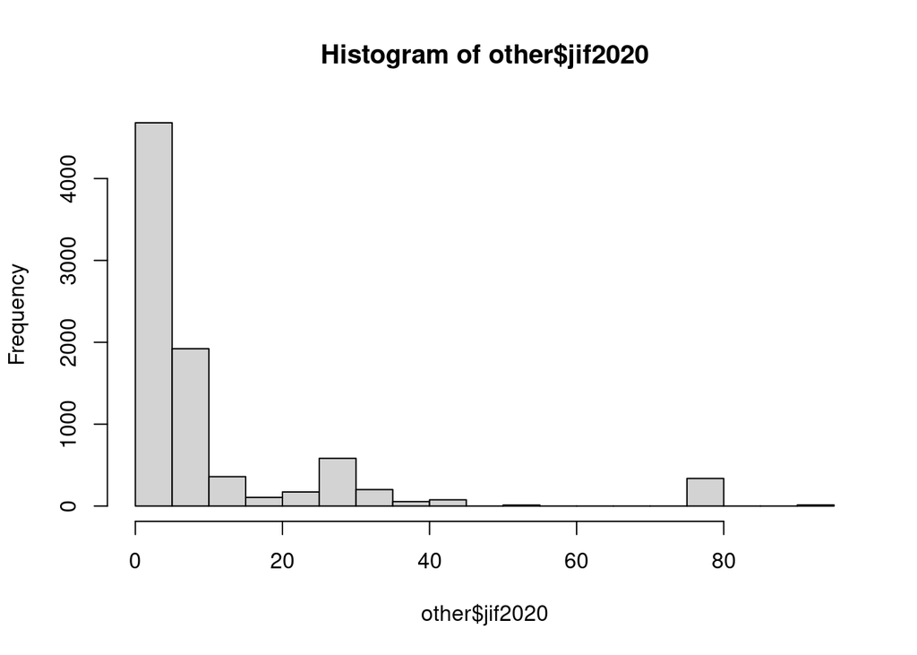

```r
hist(other$jif2020)
```

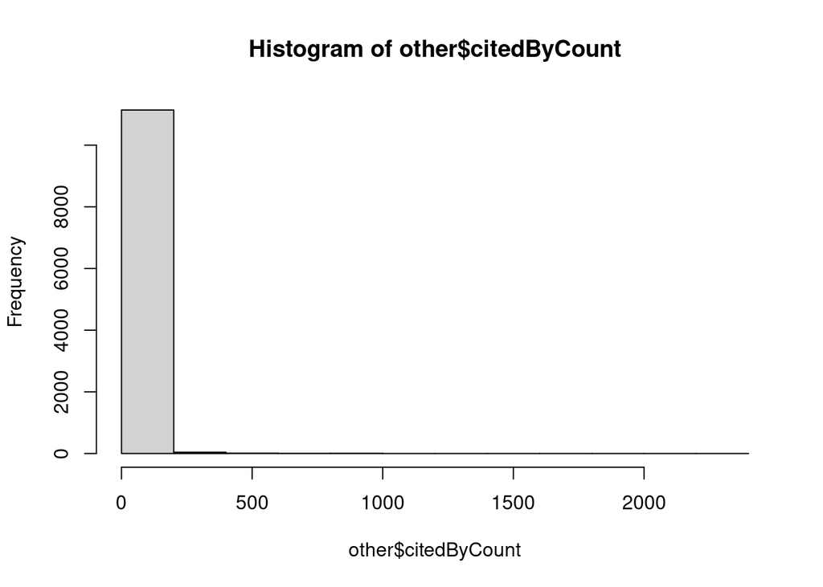

```r
hist(other$citedByCount)
```

```r
ad.test(other$jif2020)
```

```
##
##  Anderson-Darling normality test
##
## data:  other$jif2020
## A = 1344.6, p-value < 2.2e-16
```

```r
ad.test(other$citedByCount)
```

```
##
##  Anderson-Darling normality test
##
## data:  other$citedByCount
## A = 2911.1, p-value < 2.2e-16
```

JIF and citations based on COI disclosure:

```r
kable(other %>%
  group_by(is_coi_pred) %>%
  summarise(Median = round(median(jif2020, na.rm = T), 1),
            IQR = round(IQR(jif2020, na.rm = T), 2)))
```

| is_coi_pred | Median | IQR |
| --- | --- | --- |
| FALSE | 4.6 | 11.22 |
| TRUE | 4.3 | 5.25 |

```r
kable(other %>%
  group_by(is_coi_pred) %>%
  summarise(Median = round(median(citedByCount, na.rm = T), 1),
            IQR = round(IQR(citedByCount, na.rm = T), 2)))
```

| is_coi_pred | Median | IQR |
| --- | --- | --- |
| FALSE | 1 | 5 |
| TRUE | 2 | 6 |

Data was not normally distributed, hence we will use unpaired two-samples Wilcoxon test.

```r
wilcox.test(jif2020~is_coi_pred, data = other, exact = FALSE)
```

```
##
##  Wilcoxon rank sum test with continuity correction
##
## data:  jif2020 by is_coi_pred
## W = 7302070, p-value = 0.005853
## alternative hypothesis: true location shift is not equal to 0
```

```r
wilcox.test(citedByCount~is_coi_pred, data = other, exact = FALSE)
```

```
##
##  Wilcoxon rank sum test with continuity correction
##
## data:  citedByCount by is_coi_pred
## W = 10381104, p-value = 4.038e-14
## alternative hypothesis: true location shift is not equal to 0
```

JIF and citations based on funding disclosure:

```r
kable(other %>%
  group_by(is_fund_pred) %>%
  summarise(Median = round(median(jif2020, na.rm = T), 1),
            IQR = round(IQR(jif2020, na.rm = T), 2)))
```

| is_fund_pred | Median | IQR |
| --- | --- | --- |
| FALSE | 4.7 | 16.26 |
| TRUE | 4.0 | 3.97 |

```r
kable(other %>%
  group_by(is_fund_pred) %>%
  summarise(Median = round(median(citedByCount, na.rm = T), 1),
            IQR = round(IQR(citedByCount, na.rm = T), 2)))
```

| is_fund_pred | Median | IQR |
| --- | --- | --- |
| FALSE | 1 | 6 |
| TRUE | 2 | 6 |

Data was not normally distributed, hence we will use unpaired two-samples Wilcoxon test.

```r
wilcox.test(jif2020~is_fund_pred, data = other, exact = FALSE)
```

```
##
##  Wilcoxon rank sum test with continuity correction
##
## data:  jif2020 by is_fund_pred
## W = 10076000, p-value < 2.2e-16
## alternative hypothesis: true location shift is not equal to 0
```

```r
wilcox.test(citedByCount~is_fund_pred, data = other, exact = FALSE)
```

```
##
##  Wilcoxon rank sum test with continuity correction
##
## data:  citedByCount by is_fund_pred
## W = 15330056, p-value = 0.04418
## alternative hypothesis: true location shift is not equal to 0
```

JIF and citations based on data sharing:

```r
kable(other %>%
  group_by(is_open_data) %>%
  summarise(Median = round(median(jif2020, na.rm = T), 1),
            IQR = round(IQR(jif2020, na.rm = T), 2)))
```

| is_open_data | Median | IQR |
| --- | --- | --- |
| FALSE | 4.3 | 5.57 |
| TRUE | 5.2 | 6.81 |

```r
kable(other %>%
  group_by(is_open_data) %>%
  summarise(Median = round(median(citedByCount, na.rm = T), 1),
            IQR = round(IQR(citedByCount, na.rm = T), 2)))
```

| is_open_data | Median | IQR |
| --- | --- | --- |
| FALSE | 2 | 6.00 |
| TRUE | 3 | 12.75 |

Data was not normally distributed, hence we will use unpaired two-samples Wilcoxon test.

```r
wilcox.test(jif2020~is_open_data, data = other, exact = FALSE)
```

```
##
##  Wilcoxon rank sum test with continuity correction
##
## data:  jif2020 by is_open_data
## W = 643520, p-value = 0.1154
## alternative hypothesis: true location shift is not equal to 0
```

```r
wilcox.test(citedByCount~is_open_data, data = other, exact = FALSE)
```

```
##
##  Wilcoxon rank sum test with continuity correction
##
## data:  citedByCount by is_open_data
## W = 821136, p-value = 1.884e-06
## alternative hypothesis: true location shift is not equal to 0
```

JIF and citations based on code sharing:

```r
kable(other %>%
  group_by(is_open_code) %>%
  summarise(Median = round(median(jif2020, na.rm = T), 1),
            IQR = round(IQR(jif2020, na.rm = T), 2)))
```

| is_open_code | Median | IQR |
| --- | --- | --- |
| FALSE | 4.3 | 5.57 |
| TRUE | 7.7 | 19.67 |

```r
kable(other %>%
  group_by(is_open_code) %>%
  summarise(Median = round(median(citedByCount, na.rm = T), 1),
            IQR = round(IQR(citedByCount, na.rm = T), 2)))
```

| is_open_code | Median | IQR |
| --- | --- | --- |
| FALSE | 2 | 6 |
| TRUE | 3 | 11 |

Data was not normally distributed, hence we will use unpaired two-samples Wilcoxon test.

```r
wilcox.test(jif2020~is_open_code, data = other, exact = FALSE)
```

```
##
##  Wilcoxon rank sum test with continuity correction
##
## data:  jif2020 by is_open_code
## W = 152093, p-value = 2.297e-07
## alternative hypothesis: true location shift is not equal to 0
```

```r
wilcox.test(citedByCount~is_open_code, data = other, exact = FALSE)
```

```
##
##  Wilcoxon rank sum test with continuity correction
##
## data:  citedByCount by is_open_code
## W = 306350, p-value = 0.009605
## alternative hypothesis: true location shift is not equal to 0
```

## Monthly trend

Figure 1:

```r
proportions <- other %>%
        summarise("COI Disclosure" = sum(is_coi_pred == TRUE),
                  "Funding disclosure" = sum(is_fund_pred == TRUE),
                  "Protocol registration" = sum(is_register_pred == TRUE),
                  "Data sharing" = sum(is_open_data == TRUE),
                  "Code sharing" = sum(is_open_code == TRUE)) %>%
        t() %>%
        as.data.frame() %>%
        rownames_to_column(var = "indicator") %>%
        mutate(percentage = round(V1/nrow(other)*100, 1))

p1 <- proportions %>% ggplot() +
        aes(x = reorder(indicator, V1),
            y = V1,
            fill = indicator,
            col = indicator) +
        geom_col(alpha = 0.75) +
        geom_text(aes(label = percentage), hjust = -0.1, size = 3) +
        scale_y_continuous(
                name = "\nNumber of articles (in ten thousands)",
                breaks = seq(0, 10E4, 5E4),
                labels = seq(0, 10, 5),
                expand = expansion(mult = c(0, 0.2))
                ) +
        coord_flip() +
        xlab(NULL) +
        theme(
                legend.position = "none",
                panel.grid.major.y = element_blank()
        )
```

For the line grapht, first, we add the real publication year and month to the datasets. The real publication year/month is the year/month the paper was first appear online stored in firstPublicationDate column.

```r
other$YearMonth <- format(as.Date(other$firstPublicationDate), "%Y-%m")
```

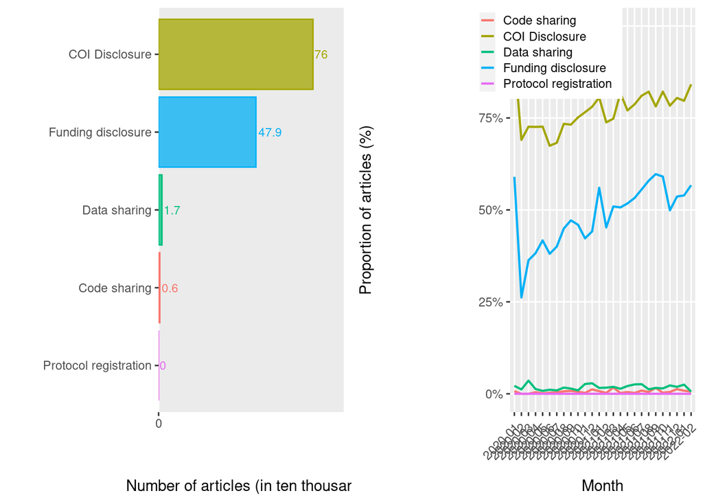

```r
indicator_by_year <-
        other %>%
        select(YearMonth,
               is_coi_pred,
               is_fund_pred,
               is_register_pred,
               is_open_data,
               is_open_code) %>%
        gather("indicator", "value", -YearMonth) %>%
        count(YearMonth, indicator, value) %>%
        mutate(indicator = recode(indicator,
                                  is_coi_pred = "COI Disclosure",
                                  is_fund_pred = "Funding disclosure",
                                  is_register_pred = "Protocol registration",
                                  is_open_data = "Data sharing",
                                  is_open_code = "Code sharing")) %>%
        complete(indicator, value, YearMonth, fill = list(n = 0)) %>%
        group_by(YearMonth, indicator) %>%
        mutate(p = n / sum(n)) %>%
        filter(value) %>%
        ungroup()

p2 <-
        indicator_by_year %>%
        ggplot() +
        aes(x = YearMonth,
            y = p,
            group = indicator,
            color = indicator) +
        geom_line(size = 0.75) +
        scale_y_continuous(limits = c(0, 1),
                           labels = scales::percent) +
        scale_color_discrete(name = NULL) +
        scale_fill_discrete(breaks = c("COI Disclosure",
                                       "Funding disclosure",
                                       "Protocol registration",
                                       "Data sharing",
                                       "Code sharing")) +
        labs(y = "Proportion of articles (%)\n",
             x = "\nMonth") +
        theme(panel.grid.minor = element_blank(),
              legend.position = c(0.2, 0.9),
              axis.text.x = element_text(angle = 45, vjust = 0.9, hjust=1),
              legend.key.size = unit(0.4, 'cm')
              )

figure <- ggarrange(p1, p2,
                    ncol = 2, nrow = 1,
                    align = "hv", common.legend = F)

# tiff("Figure.tiff", width = 14, height = 7, units = "in", res = 300)
figure
```

```r
#dev.off()
```

# Appendix

## Journals

Total number of papers published in journals with an SJR:

```r
table(is.na(opendata$sjr2020))
```

```
##
##  FALSE   TRUE
## 112080  20518
```

Top five journals in SJR:

```r
tapply(opendata$sjr2020, opendata$journalTitle, max) %>% as.data.frame() %>% arrange(desc(.)) %>% head(5)
```

```
##                            .
## CA Cancer J Clin      62.937
## MMWR Recomm Rep       40.949
## Nat Rev Mol Cell Biol 37.461
## Nat Rev Mater         32.011
## Cell                  26.304
```

```r
opendata$sjr2020c = ifelse(opendata$sjr2020 < 26.304,"Other", opendata$journalTitle)
```

Table S1

```r
set.seed(100)
opendata %>%
  select(sjr2020c,is_coi_pred,is_fund_pred,is_register_pred,is_open_data,is_open_code) %>%
  tbl_summary(by=sjr2020c, percent="column",
              label = c(is_coi_pred ~ "COI disclosure", is_fund_pred ~ "Funding disclosure", is_register_pred ~ "Protocol registration", is_open_data ~ "Data sharing", is_open_code ~ "Code sharing")) %>%
  add_p(test.args=all_tests("fisher.test") ~ list(simulate.p.value=TRUE)) %>%
        as_flex_table()
```

```
## 20518 observations missing `sjr2020c` have been removed. To include these observations, use `forcats::fct_explicit_na()` on `sjr2020c` column before passing to `tbl_summary()`.
```

| Characteristic | CA Cancer J Clin, N = 41 | Cell, N = 1861 | MMWR Recomm Rep, N = 11 | Nat Rev Mater, N = 51 | Nat Rev Mol Cell Biol, N = 81 | Other, N = 111,8761 | p-value2 |
| --- | --- | --- | --- | --- | --- | --- | --- |
| COI disclosure | 2 (50%) | 166 (89%) | 1 (100%) | 4 (80%) | 6 (75%) | 96,472 (86%) | 0.14 |
| Funding disclosure | 1 (25%) | 164 (88%) | 1 (100%) | 4 (80%) | 3 (38%) | 77,101 (69%) | <0.001 |
| Protocol registration | 0 (0%) | 12 (6.5%) | 0 (0%) | 0 (0%) | 0 (0%) | 4,059 (3.6%) | 0.3 |
| Data sharing | 0 (0%) | 125 (67%) | 0 (0%) | 0 (0%) | 0 (0%) | 10,178 (9.1%) | <0.001 |
| Code sharing | 0 (0%) | 56 (30%) | 0 (0%) | 0 (0%) | 0 (0%) | 3,484 (3.1%) | <0.001 |

1n (%)  
2Fisher's Exact Test for Count Data with simulated p-value (based on 2000 replicates)

Top five journals in H-index:

```r
tapply(opendata$scimago_hindex, opendata$journalTitle, max) %>% as.data.frame() %>% arrange(desc(.)) %>% head(5)
```

```
##                             .
## Nature                   1226
## Science                  1186
## N Engl J Med             1030
## Cell                      776
## Proc Natl Acad Sci U S A  771
```

```r
opendata$hindexc = ifelse(opendata$scimago_hindex < 771,"Other", opendata$journalTitle)
```

Table S2

```r
set.seed(100)
opendata %>%
  select(hindexc,is_coi_pred,is_fund_pred,is_register_pred,is_open_data,is_open_code) %>%
  tbl_summary(by=hindexc, percent="column",
              label = c(is_coi_pred ~ "COI disclosure", is_fund_pred ~ "Funding disclosure", is_register_pred ~ "Protocol registration", is_open_data ~ "Data sharing", is_open_code ~ "Code sharing")) %>%
  add_p(test.args=all_tests("fisher.test") ~ list(simulate.p.value=TRUE)) %>%
        as_flex_table()
```

```
## 20263 observations missing `hindexc` have been removed. To include these observations, use `forcats::fct_explicit_na()` on `hindexc` column before passing to `tbl_summary()`.
```

| Characteristic | Cell, N = 1861 | N Engl J Med, N = 1181 | Nature, N = 521 | Other, N = 111,5321 | Proc Natl Acad Sci U S A, N = 3241 | Science, N = 1231 | p-value2 |
| --- | --- | --- | --- | --- | --- | --- | --- |
| COI disclosure | 166 (89%) | 117 (99%) | 52 (100%) | 96,120 (86%) | 319 (98%) | 122 (99%) | <0.001 |
| Funding disclosure | 164 (88%) | 82 (69%) | 52 (100%) | 76,774 (69%) | 286 (88%) | 123 (100%) | <0.001 |
| Protocol registration | 12 (6.5%) | 24 (20%) | 2 (3.8%) | 4,045 (3.6%) | 1 (0.3%) | 0 (0%) | <0.001 |
| Data sharing | 125 (67%) | 3 (2.5%) | 41 (79%) | 9,863 (8.8%) | 192 (59%) | 82 (67%) | <0.001 |
| Code sharing | 56 (30%) | 1 (0.8%) | 21 (40%) | 3,358 (3.0%) | 87 (27%) | 19 (15%) | <0.001 |

1n (%)  
2Pearson's Chi-squared test; Fisher's Exact Test for Count Data with simulated p-value (based on 2000 replicates)

## Appendix 3:

Correct p-values (considering all levels)

```r
opendata %>%
  select(journalTitle,is_coi_pred) %>%
        table() %>%
        fisher.test(simulate.p.value=TRUE)
```

```
##
##  Fisher's Exact Test for Count Data with simulated p-value (based on
##  2000 replicates)
##
## data:  .
## p-value = 0.0004998
## alternative hypothesis: two.sided
```

```r
opendata %>%
  select(journalTitle,is_fund_pred) %>%
        table() %>%
        fisher.test(simulate.p.value=TRUE)
```

```
##
##  Fisher's Exact Test for Count Data with simulated p-value (based on
##  2000 replicates)
##
## data:  .
## p-value = 0.0004998
## alternative hypothesis: two.sided
```

```r
opendata %>%
  select(journalTitle,is_register_pred) %>%
        table() %>%
        fisher.test(simulate.p.value=TRUE)
```

```
##
##  Fisher's Exact Test for Count Data with simulated p-value (based on
##  2000 replicates)
##
## data:  .
## p-value = 0.0004998
## alternative hypothesis: two.sided
```

```r
opendata %>%
  select(journalTitle,is_open_data) %>%
        table() %>%
        fisher.test(simulate.p.value=TRUE)
```

```
##
##  Fisher's Exact Test for Count Data with simulated p-value (based on
##  2000 replicates)
##
## data:  .
## p-value = 0.0004998
## alternative hypothesis: two.sided
```

```r
opendata %>%
  select(journalTitle,is_open_code) %>%
        table() %>%
        fisher.test(simulate.p.value=TRUE)
```

```
##
##  Fisher's Exact Test for Count Data with simulated p-value (based on
##  2000 replicates)
##
## data:  .
## p-value = 0.0004998
## alternative hypothesis: two.sided
```

# Publisher-related differences in transparency

Correct p-values (considering all levels)

```r
opendata %>%
  select(scimago_publisher,is_coi_pred) %>%
        table() %>%
        fisher.test(simulate.p.value=TRUE)
```

```
##
##  Fisher's Exact Test for Count Data with simulated p-value (based on
##  2000 replicates)
##
## data:  .
## p-value = 0.0004998
## alternative hypothesis: two.sided
```

```r
opendata %>%
  select(scimago_publisher,is_fund_pred) %>%
        table() %>%
        fisher.test(simulate.p.value=TRUE)
```

```
##
##  Fisher's Exact Test for Count Data with simulated p-value (based on
##  2000 replicates)
##
## data:  .
## p-value = 0.0004998
## alternative hypothesis: two.sided
```

```r
opendata %>%
  select(scimago_publisher,is_register_pred) %>%
        table() %>%
        fisher.test(simulate.p.value=TRUE)
```

```
##
##  Fisher's Exact Test for Count Data with simulated p-value (based on
##  2000 replicates)
##
## data:  .
## p-value = 0.0004998
## alternative hypothesis: two.sided
```

```r
opendata %>%
  select(scimago_publisher,is_open_data) %>%
        table() %>%
        fisher.test(simulate.p.value=TRUE)
```

```
##
##  Fisher's Exact Test for Count Data with simulated p-value (based on
##  2000 replicates)
##
## data:  .
## p-value = 0.0004998
## alternative hypothesis: two.sided
```

```r
opendata %>%
  select(scimago_publisher,is_open_code) %>%
        table() %>%
        fisher.test(simulate.p.value=TRUE)
```

```
##
##  Fisher's Exact Test for Count Data with simulated p-value (based on
##  2000 replicates)
##
## data:  .
## p-value = 0.0004998
## alternative hypothesis: two.sided
```